# MLB_Project

MLB Project

How Can We Find The Greatest Batters In The League?

To use this Notebook feel free to download the data set from Kaggle (sqlite file) and rename it database.sqlite and make sure its in the same directory as the notebook. The link is posted below.  
Sources:  
https://www.kaggle.com/seanlahman/the-history-of-baseball  
https://mlb.nbcsports.com/2020/03/13/looking-back-at-baseballs-previously-shortened-seasons/  
Note:  
Lists, DataFrames and Functions are listed in the Table of Contents.

Table of Contents

## 1.0 SQL Queries

> 1.1 Create List of Tuples from SQL Query  
> 1.2 Create DataFrame from SQL Query  
> - teamStats_df  
> - listTeamId  
> - dictTeamId *Use this to find team id's based off team name.*  
> 1.3 SQL Query with Conditions and Order By  
> 1.4 SQL Query with Inner Join

## 2.0 Gathering and Cleaning Data

> 2.1 Query Batting Data for Regular Season  
> - regularSeason_df  
> 2.2 Check Data Type  
> 2.3 Change Data Type  
> 2.4 Generate Descriptive Statistics  
> 2.5 Check for Null Values  
> 2.6 Change Null Values to Zero for Calculations  
> 2.7 Query Data to Calc. BA, OBP and SLG for World Series Games  
> - postSeason_df

## 3.0 World Series Games Analysis

> 3.1 Filter Stats Based on Range of Years and Teams  
> - StatsFilter( )  
> 3.2 BA, OBP and SLG Calculators  
> - BACalculator( )  
> - OBPCalculator( )  
> - SLGCalculator( )  
> - PACalculator( )  
> 3.3 Apply Calculators to Create Player or Team or MLB Dataframes  
> - BattingStats( )  
> 3.4 Plot Stats for the World Series Games  
> - dictStats  
> - diffStatsValuesWS( )  
> - autoLabels( )  
> - BarChartWSStats( )  
> 3.5 Results of World Series Games

## 4.0 MLB Outliers Analysis

> 4.1 Query Hall of Fame Players and Player Names  
> - halloffame_df  
> - listHallofFame  
> - playerNames_df  
> - nameGetter( )  
> 4.2 Detect Outliers  
> - detectOutlier( )  
> - autoLabelPlot( )  
> 4.3 League Outliers Plot  
> - LeagueOutliers( )  
> 4.4 MLB Outliers Plot  
> - MLBOutliers( )  
> 4.5 Compare Stats Plot  
> - MLBTwoStats ( )

## 5.0 Results

> 5.1 Home Run Leaders per League  
> 5.2 Home Run Leaders in MLB  
> 5.3 Compare Stats  
> 5.4 Triple Crown

```python
import sqlite3
import pandas as pd
import numpy as np
import jinjasql
import six
import matplotlib.pyplot as plt
import seaborn as sns

from pandas import DataFrame
from jinjasql import JinjaSql
from six import string_types
from copy import deepcopy
from scipy import stats

# Connect with the database
connection = sqlite3.connect('database.sqlite')
```

1.1 Create List of Tuples from SQL Query

- **Not going to be used but demonstrates an alternative to gathering data.**

```python
# Cursor object.
crsr = connection.cursor()

# Execute the command to fetch all the data from the table.
crsr.execute('''

    SELECT *
    FROM team;
''')

# Store all the fetched data.
teams_list = crsr.fetchall()

print(teams_list[0])
print('teams_list Type:  ' + str(type(teams_list)))
print('teams_list Element Type:  ' + str(type(teams_list[0])))
print('Select 1st tuple and 4th item:  ' + teams_list[0][3])
#Create list of column 4
li5t = [lis[3] for lis in teams_list]
```

```
(1871, '', 'BS1', 'BNA', '', 3, 31, '', 20, 10, '', '', 'N', '', 401, 1372, 426, 70, 37, 3, 60, 19, 73, '', '', '', 303, 109, 3.55, 22, 1, 3, 828, 367, 2, 42, 23, 225, '', 0.83, 'Boston Red Stockings', 'South End Grounds I', '', 103, 98, 'BOS', 'BS1', 'BS1')
teams_list Type:  <class 'list'>
teams_list Element Type:  <class 'tuple'>
Select 1st tuple and 4th item:  BNA
```

1.2 Create DataFrame from SQL Query

- **Use pd.read_sql_query() to create team stats dataframe**
- **List of Teams Id's**
- **Dictionary of Team Names**

```python
teamStats_df = pd.read_sql_query('''

    SELECT*
    FROM team;
    ''', connection)

pd.set_option('display.max_columns',None)
teamStats_df.head()
```

|  | year | league_id | team_id | franchise_id | div_id | rank | g | ghome | w | l | div_win | wc_win | lg_win | ws_win | r | ab | h | double | triple | hr | bb | so | sb | cs | hbp | sf | ra | er | era | … |
| --- | --- | --- | --- | --- | --- | --- | --- | --- | --- | --- | --- | --- | --- | --- | --- | --- | --- | --- | --- | --- | --- | --- | --- | --- | --- | --- | --- | --- | --- | --- |
| 0 | 1871 |  | BS1 | BNA |  | 3 | 31 |  | 20 | 10 |  |  | N |  | 401 | 1372 | 426 | 70 | 37 | 3 | 60 | 19 | 73 |  |  |  | 303 | 109 | 3.55 | … |
| 1 | 1871 |  | CH1 | CNA |  | 2 | 28 |  | 19 | 9 |  |  | N |  | 302 | 1196 | 323 | 52 | 21 | 10 | 60 | 22 | 69 |  |  |  | 241 | 77 | 2.76 | … |
| 2 | 1871 |  | CL1 | CFC |  | 8 | 29 |  | 10 | 19 |  |  | N |  | 249 | 1186 | 328 | 35 | 40 | 7 | 26 | 25 | 18 |  |  |  | 341 | 116 | 4.11 | … |
| 3 | 1871 |  | FW1 | KEK |  | 7 | 19 |  | 7 | 12 |  |  | N |  | 137 | 746 | 178 | 19 | 8 | 2 | 33 | 9 | 16 |  |  |  | 243 | 97 | 5.17 | … |
| 4 | 1871 |  | NY2 | NNA |  | 5 | 33 |  | 16 | 17 |  |  | N |  | 302 | 1404 | 403 | 43 | 21 | 1 | 33 | 15 | 46 |  |  |  | 313 | 121 | 3.72 | … |

### List of Team Id's

```python
listTeamIds = teamStats_df.loc[:, 'team_id'].unique()

# Example: Print out 8 Id's.
print(listTeamIds[0:8])
```

```
['BS1' 'CH1' 'CL1' 'FW1' 'NY2' 'PH1' 'RC1' 'TRO']
```

### Dictionary of Team Id's to Team Names

```python
dictTeamIds = pd.Series( teamStats_df['name'].values, index=teamStats_df['team_id']).to_dict()

# Example: Print out Name of Id BS1.
#print(dictTeamIds.get('BS1'))
for key in sorted(dictTeamIds.keys()):
    print("%s: %s" % (key, dictTeamIds[key]))
```

```
ALT: Altoona Mountain City
ANA: Anaheim Angels
ARI: Arizona Diamondbacks
ATL: Atlanta Braves
BAL: Baltimore Orioles
BFN: Buffalo Bisons
BFP: Buffalo Bisons
BL1: Baltimore Canaries
BL2: Baltimore Orioles
BL3: Baltimore Orioles
BL4: Baltimore Marylands
BLA: Baltimore Orioles
BLF: Baltimore Terrapins
BLN: Baltimore Orioles
BLU: Baltimore Monumentals
BOS: Boston Red Sox
BR1: Brooklyn Eckfords
BR2: Brooklyn Atlantics
BR3: Brooklyn Bridegrooms
BR4: Brooklyn Gladiators
BRF: Brooklyn Tip-Tops
BRO: Brooklyn Dodgers
BRP: Brooklyn Ward's Wonders
BS1: Boston Red Stockings
BS2: Boston Reds
BSN: Boston Braves
BSP: Boston Reds
BSU: Boston Reds
BUF: Buffalo Blues
CAL: California Angels
CH1: Chicago White Stockings
CH2: Chicago White Stockings
CHA: Chicago White Sox
CHF: Chicago Whales
CHN: Chicago Cubs
CHP: Chicago Pirates
CHU: Chicago/Pittsburgh (Union League)
CIN: Cincinnati Reds
CL1: Cleveland Forest Citys
CL2: Cleveland Blues
```

[output cut: 94 more lines]

```
TRN: Troy Trojans
TRO: Troy Haymakers
WAS: Washington Nationals
WIL: Wilmington Quicksteps
WOR: Worcester Ruby Legs
WS1: Washington Senators
WS2: Washington Senators
WS3: Washington Olympics
WS4: Washington Nationals
WS5: Washington Blue Legs
WS6: Washington Nationals
WS7: Washington Nationals
WS8: Washington Nationals
WS9: Washington Statesmen
WSU: Washington Nationals
```

1.3 SQL Query with Conditions and Order By

- **Examples to demonstrate SQL Queries**

### Choose all star players from 'NYA' and 'DET' teams

```python
all_star_condition_df = pd.read_sql_query('''

    SELECT*
    FROM all_star
    WHERE team_id = "NYA" OR team_id = "DET"
    ORDER BY team_id;
    ''', connection)

all_star_condition_df.head()
```

|  | player_id | year | game_num | game_id | team_id | league_id | gp | starting_pos |
| --- | --- | --- | --- | --- | --- | --- | --- | --- |
| 0 | gehrich01 | 1933 | 0 | ALS193307060 | DET | AL | 1 | 4 |
| 1 | gehrich01 | 1934 | 0 | NLS193407100 | DET | AL | 1 | 4 |
| 2 | bridgto01 | 1934 | 0 | NLS193407100 | DET | AL | 0 |  |
| 3 | cochrmi01 | 1934 | 0 | NLS193407100 | DET | AL | 1 |  |
| 4 | gehrich01 | 1935 | 0 | ALS193507080 | DET | AL | 1 | 4 |

### Number of players from each team that played in the All Star games from 1980 - 2000

```python
all_star_timeperiod = pd.read_sql_query('''

    SELECT team_id
        , count(team_id) AS num_players
    FROM all_star
    WHERE year >=1980 AND year <=2000
    GROUP BY team_id;
    ''', connection)

all_star_timeperiod.head()
```

|  | team_id | num_players |
| --- | --- | --- |
| 0 | ANA | 6 |
| 1 | ARI | 7 |
| 2 | ATL | 60 |
| 3 | BAL | 51 |
| 4 | BOS | 52 |

### The percentage of each teams participation in the All Star Games from 1980 to 2000

```python
total_players = all_star_timeperiod['num_players'].sum()
all_star_timeperiod['participation_pct'] = all_star_timeperiod['num_players'] / total_players

all_star_timeperiod
```

|  | team_id | num_players | participation_pct |
| --- | --- | --- | --- |
| 0 | ANA | 6 | 0.004766 |
| 1 | ARI | 7 | 0.005560 |
| 2 | ATL | 60 | 0.047657 |
| 3 | BAL | 51 | 0.040508 |
| 4 | BOS | 52 | 0.041303 |
| 5 | CAL | 37 | 0.029388 |
| 6 | CHA | 34 | 0.027006 |
| 7 | CHN | 45 | 0.035743 |
| 8 | CIN | 55 | 0.043685 |
| 9 | CLE | 56 | 0.044480 |
| 10 | COL | 16 | 0.012708 |
| 11 | DET | 43 | 0.034154 |
| 12 | FLO | 13 | 0.010326 |
| 13 | HOU | 42 | 0.033360 |
| 14 | KCA | 38 | 0.030183 |
| 15 | LAN | 55 | 0.043685 |
| 16 | MIL | 4 | 0.003177 |
| 17 | MIN | 33 | 0.026211 |
| 18 | ML4 | 31 | 0.024623 |
| 19 | MON | 51 | 0.040508 |
| 20 | NYA | 69 | 0.054805 |
| 21 | NYN | 46 | 0.036537 |
| 22 | OAK | 45 | 0.035743 |
| 23 | PHI | 51 | 0.040508 |
| 24 | PIT | 37 | 0.029388 |
| 25 | SDN | 50 | 0.039714 |
| 26 | SEA | 39 | 0.030977 |
| 27 | SFN | 45 | 0.035743 |
| 28 | SLN | 53 | 0.042097 |
| 29 | TBA | 5 | 0.003971 |
| 30 | TEX | 40 | 0.031771 |
| 31 | TOR | 50 | 0.039714 |

1.4 SQL Query with Inner Join

- **Examples to demonstrate SQL Queries**

### View stats of players during regular season and post season (Only players that played in Post Season)

```python
RseasonPseason= pd.read_sql_query('''

    SELECT b.*
        , bps.round AS round_Pseason
        , bps.g AS g_Pseason
        , bps.ab AS ab_Pseason
        , bps.r AS r_Pseason
        , bps.h AS h_Pseason
        , bps.double AS double_Pseason
        , bps.triple AS triple_Pseason
        , bps.hr AS hr_Pseason
        , bps.rbi AS rbi_Pseason
        , bps.sb AS sb_Pseason
        , bps.cs AS cs_Pseason
        , bps.bb AS bb_Pseason
        , bps.so AS so_Pseason
        , bps.ibb AS ibb_Pseason
        , bps.hbp AS hbp_Pseason
        , bps.sh AS sh_Pseason
        , bps.sf AS sf_Pseason
        , bps.g_idp AS g_idp_Pseason
    FROM batting AS b
    INNER JOIN batting_postseason AS bps
    ON b.player_id = bps.player_id
    AND b.year = bps.year;
    ''', connection, coerce_float = True)

pd.set_option('display.max_columns',None)

RseasonPseason.head()
```

|  | player_id | year | stint | team_id | league_id | g | ab | r | h | double | triple | hr | rbi | sb | cs | bb | so | ibb | hbp | sh | sf | g_idp | round_Pseason | g_Pseason | ab_Pseason | r_Pseason | h_Pseason | double_Pseason | triple_Pseason | … |
| --- | --- | --- | --- | --- | --- | --- | --- | --- | --- | --- | --- | --- | --- | --- | --- | --- | --- | --- | --- | --- | --- | --- | --- | --- | --- | --- | --- | --- | --- | --- |
| 0 | becanbu01 | 1884 | 1 | NY4 | AA | 1 | 3 | 0 | 0 | 0 | 0 | 0 | 0 | 0 |  | 0 |  |  | 0 |  |  |  | WS | 1 | 2 | 0 | 1 | 0 | 0 | … |
| 1 | bradyst01 | 1884 | 1 | NY4 | AA | 112 | 485 | 102 | 122 | 11 | 3 | 1 | 0 | 0 |  | 21 |  |  | 0 |  |  |  | WS | 3 | 10 | 1 | 0 | 0 | 0 | … |
| 2 | carrocl01 | 1884 | 1 | PRO | NL | 113 | 452 | 90 | 118 | 16 | 4 | 3 | 54 |  |  | 29 | 39 |  |  |  |  |  | WS | 3 | 10 | 2 | 1 | 0 | 0 | … |
| 3 | dennyje01 | 1884 | 1 | PRO | NL | 110 | 439 | 57 | 109 | 22 | 9 | 6 | 59 |  |  | 14 | 58 |  |  |  |  |  | WS | 3 | 9 | 3 | 4 | 0 | 1 | … |
| 4 | esterdu01 | 1884 | 1 | NY4 | AA | 112 | 477 | 110 | 150 | 29 | 11 | 1 | 0 | 0 |  | 12 |  |  | 10 |  |  |  | WS | 3 | 10 | 0 | 3 | 1 | 0 | … |

2.1 Query Batting Data for Regular Season

- **Query from batting table and inner join the ws_win column from team table that indicates if that team won the world series.**

```python
regularSeason_df = pd.read_sql_query('''

    SELECT b.*
                    , t.ws_win
    FROM batting AS b
    INNER JOIN team as t
    ON b.year = t.year
    AND b.team_id = t.team_id;
    ''', connection)
```

2.2 Check Data Types

- **.info() or .dtypes()**
- **There are object types where there should be numerical types. This could be because '' was used for Null values.**

```python
regularSeason_df.info()
```

```
<class 'pandas.core.frame.DataFrame'>
RangeIndex: 101332 entries, 0 to 101331
Data columns (total 23 columns):
 #   Column     Non-Null Count   Dtype
---  ------     --------------   -----
 0   player_id  101332 non-null  object
 1   year       101332 non-null  int64
 2   stint      101332 non-null  int64
 3   team_id    101332 non-null  object
 4   league_id  101332 non-null  object
 5   g          101332 non-null  int64
 6   ab         101332 non-null  object
 7   r          101332 non-null  object
 8   h          101332 non-null  object
 9   double     101332 non-null  object
 10  triple     101332 non-null  object
 11  hr         101332 non-null  object
 12  rbi        101332 non-null  object
 13  sb         101332 non-null  object
 14  cs         101332 non-null  object
 15  bb         101332 non-null  object
 16  so         101332 non-null  object
 17  ibb        101332 non-null  object
 18  hbp        101332 non-null  object
 19  sh         101332 non-null  object
 20  sf         101332 non-null  object
 21  g_idp      101332 non-null  object
 22  ws_win     101332 non-null  object
dtypes: int64(3), object(20)
memory usage: 17.8+ MB
```

2.3 Change Data Type

- **Manually Change Data Type To Numerical**
- **Create list of columns that need to be changed**
- **.apply(pd.to_numeric)**

```python
changeToNumeric = ['ab', 'r', 'h', 'double', 'triple', 'hr', 'rbi', 'sb', 'cs', 'bb', 'so', 'ibb', 'hbp', 'sh', 'sf', 'g_idp']
regularSeason_df[changeToNumeric] = regularSeason_df[changeToNumeric].apply(pd.to_numeric)
pd.set_option('display.max_columns',None)
regularSeason_df.head()
```

|  | player_id | year | stint | team_id | league_id | g | ab | r | h | double | triple | hr | rbi | sb | cs | bb | so | ibb | hbp | sh | sf | g_idp | ws_win |
| --- | --- | --- | --- | --- | --- | --- | --- | --- | --- | --- | --- | --- | --- | --- | --- | --- | --- | --- | --- | --- | --- | --- | --- |
| 0 | abercda01 | 1871 | 1 | TRO |  | 1 | 4.0 | 0.0 | 0.0 | 0.0 | 0.0 | 0.0 | 0.0 | 0.0 | 0.0 | 0.0 | 0.0 | NaN | NaN | NaN | NaN | NaN |  |
| 1 | addybo01 | 1871 | 1 | RC1 |  | 25 | 118.0 | 30.0 | 32.0 | 6.0 | 0.0 | 0.0 | 13.0 | 8.0 | 1.0 | 4.0 | 0.0 | NaN | NaN | NaN | NaN | NaN |  |
| 2 | allisar01 | 1871 | 1 | CL1 |  | 29 | 137.0 | 28.0 | 40.0 | 4.0 | 5.0 | 0.0 | 19.0 | 3.0 | 1.0 | 2.0 | 5.0 | NaN | NaN | NaN | NaN | NaN |  |
| 3 | allisdo01 | 1871 | 1 | WS3 |  | 27 | 133.0 | 28.0 | 44.0 | 10.0 | 2.0 | 2.0 | 27.0 | 1.0 | 1.0 | 0.0 | 2.0 | NaN | NaN | NaN | NaN | NaN |  |
| 4 | ansonca01 | 1871 | 1 | RC1 |  | 25 | 120.0 | 29.0 | 39.0 | 11.0 | 3.0 | 0.0 | 16.0 | 6.0 | 2.0 | 2.0 | 1.0 | NaN | NaN | NaN | NaN | NaN |  |

```python
regularSeason_df.dtypes
```

```
player_id     object
year           int64
stint          int64
team_id       object
league_id     object
g              int64
ab           float64
r            float64
h            float64
double       float64
triple       float64
hr           float64
rbi          float64
sb           float64
cs           float64
bb           float64
so           float64
ibb          float64
hbp          float64
sh           float64
sf           float64
g_idp        float64
ws_win        object
dtype: object
```

```python
regularSeason_df.head()
```

|  | player_id | year | stint | team_id | league_id | g | ab | r | h | double | triple | hr | rbi | sb | cs | bb | so | ibb | hbp | sh | sf | g_idp | ws_win |
| --- | --- | --- | --- | --- | --- | --- | --- | --- | --- | --- | --- | --- | --- | --- | --- | --- | --- | --- | --- | --- | --- | --- | --- |
| 0 | abercda01 | 1871 | 1 | TRO |  | 1 | 4.0 | 0.0 | 0.0 | 0.0 | 0.0 | 0.0 | 0.0 | 0.0 | 0.0 | 0.0 | 0.0 | NaN | NaN | NaN | NaN | NaN |  |
| 1 | addybo01 | 1871 | 1 | RC1 |  | 25 | 118.0 | 30.0 | 32.0 | 6.0 | 0.0 | 0.0 | 13.0 | 8.0 | 1.0 | 4.0 | 0.0 | NaN | NaN | NaN | NaN | NaN |  |
| 2 | allisar01 | 1871 | 1 | CL1 |  | 29 | 137.0 | 28.0 | 40.0 | 4.0 | 5.0 | 0.0 | 19.0 | 3.0 | 1.0 | 2.0 | 5.0 | NaN | NaN | NaN | NaN | NaN |  |
| 3 | allisdo01 | 1871 | 1 | WS3 |  | 27 | 133.0 | 28.0 | 44.0 | 10.0 | 2.0 | 2.0 | 27.0 | 1.0 | 1.0 | 0.0 | 2.0 | NaN | NaN | NaN | NaN | NaN |  |
| 4 | ansonca01 | 1871 | 1 | RC1 |  | 25 | 120.0 | 29.0 | 39.0 | 11.0 | 3.0 | 0.0 | 16.0 | 6.0 | 2.0 | 2.0 | 1.0 | NaN | NaN | NaN | NaN | NaN |  |

2.4 Generate Descriptive Statistics

- **.describe()**
- **Get a feeling for the data distribution**

```python
regularSeason_df.describe()
```

|  | year | stint | g | ab | r | h | double | triple | hr | rbi | sb | cs | bb | so | ibb | hbp | sh | sf | g_idp |
| --- | --- | --- | --- | --- | --- | --- | --- | --- | --- | --- | --- | --- | --- | --- | --- | --- | --- | --- | --- |
| count | 101332.000000 | 101332.000000 | 101332.000000 | 96183.000000 | 96183.000000 | 96183.000000 | 96183.000000 | 96183.000000 | 96183.000000 | 95759.000000 | 94883.000000 | 72729.000000 | 96183.000000 | 88345.000000 | 59620.000000 | 93373.000000 | 89845.000000 | 60151.000000 | 70075.000000 |
| mean | 1963.506533 | 1.077567 | 51.400111 | 149.970327 | 19.887038 | 39.261647 | 6.637067 | 1.373361 | 2.949305 | 17.965163 | 3.158184 | 1.324025 | 13.811484 | 21.629849 | 1.213234 | 1.113395 | 2.457900 | 1.150122 | 3.210032 |
| std | 38.628278 | 0.283676 | 47.145273 | 186.557072 | 28.671365 | 53.310941 | 9.801563 | 2.710547 | 6.409662 | 26.756514 | 7.922994 | 2.838196 | 21.092775 | 28.432978 | 2.894918 | 2.320660 | 4.347818 | 2.023981 | 4.835881 |
| min | 1871.000000 | 1.000000 | 0.000000 | 0.000000 | 0.000000 | 0.000000 | 0.000000 | 0.000000 | 0.000000 | 0.000000 | 0.000000 | 0.000000 | 0.000000 | 0.000000 | 0.000000 | 0.000000 | 0.000000 | 0.000000 | 0.000000 |
| 25% | 1933.000000 | 1.000000 | 13.000000 | 7.000000 | 0.000000 | 1.000000 | 0.000000 | 0.000000 | 0.000000 | 0.000000 | 0.000000 | 0.000000 | 0.000000 | 2.000000 | 0.000000 | 0.000000 | 0.000000 | 0.000000 | 0.000000 |
| 50% | 1972.000000 | 1.000000 | 34.000000 | 57.000000 | 5.000000 | 11.000000 | 1.000000 | 0.000000 | 0.000000 | 4.000000 | 0.000000 | 0.000000 | 3.000000 | 10.000000 | 0.000000 | 0.000000 | 1.000000 | 0.000000 | 1.000000 |
| 75% | 1997.000000 | 1.000000 | 80.250000 | 251.000000 | 30.000000 | 63.000000 | 10.000000 | 2.000000 | 3.000000 | 27.000000 | 2.000000 | 1.000000 | 20.000000 | 30.000000 | 1.000000 | 1.000000 | 3.000000 | 2.000000 | 5.000000 |
| max | 2015.000000 | 5.000000 | 165.000000 | 716.000000 | 192.000000 | 262.000000 | 67.000000 | 36.000000 | 73.000000 | 191.000000 | 138.000000 | 42.000000 | 232.000000 | 223.000000 | 120.000000 | 51.000000 | 67.000000 | 19.000000 | 36.000000 |

2.5 Check for Null Values

```python
regularSeason_df.isnull().sum()

#regularSeason_dfNull = regularSeason_df[regularSeason_df.isna().any(axis=1)]
#regularSeason_dfNull.head()
```

```
player_id        0
year             0
stint            0
team_id          0
league_id        0
g                0
ab            5149
r             5149
h             5149
double        5149
triple        5149
hr            5149
rbi           5573
sb            6449
cs           28603
bb            5149
so           12987
ibb          41712
hbp           7959
sh           11487
sf           41181
g_idp        31257
ws_win           0
dtype: int64
```

2.6 Change Null Values to Zero for Calculations

```python
#regularSeason_df.loc[regularSeason_df.year < 1954, 'sf'] = 0
#regularSeason_df.loc[regularSeason_df.year < 1895, 'sh'] = 0

regularSeason_df.isnull().sum()
```

```
player_id        0
year             0
stint            0
team_id          0
league_id        0
g                0
ab            5149
r             5149
h             5149
double        5149
triple        5149
hr            5149
rbi           5573
sb            6449
cs           28603
bb            5149
so           12987
ibb          41712
hbp           7959
sh           11487
sf           41181
g_idp        31257
ws_win           0
dtype: int64
```

2.7 Query Data to Calc. BA, OBP and SLG for World Series Games

- **Join team Table to batting_postseason Table in order to see which team won the World Series. Column(ws_win)**
- **Change object data type to numeric for certain columns**

```python
postSeason_df = pd.read_sql_query('''

    SELECT bps.*
                    , t.ws_win
    FROM batting_postseason AS bps
    INNER JOIN team as t
    ON bps.year = t.year
    AND bps.team_id = t.team_id;
    ''', connection)

# Change to data type to numeric
changeToNumeric = ['ab', 'r', 'h', 'double', 'triple', 'hr', 'rbi', 'sb', 'cs', 'bb', 'so', 'ibb', 'hbp', 'sh', 'sf', 'g_idp']
postSeason_df [changeToNumeric] = postSeason_df [changeToNumeric].apply(pd.to_numeric)
#postSeason_df.loc[postSeason_df.year < 1954, 'sf'] = 0
#postSeason_df.loc[postSeason_df.year < 1895, 'sh'] = 0

postSeason_df.head()
```

|  | year | round | player_id | team_id | league_id | g | ab | r | h | double | triple | hr | rbi | sb | cs | bb | so | ibb | hbp | sh | sf | g_idp | ws_win |
| --- | --- | --- | --- | --- | --- | --- | --- | --- | --- | --- | --- | --- | --- | --- | --- | --- | --- | --- | --- | --- | --- | --- | --- |
| 0 | 1884 | WS | becanbu01 | NY4 | AA | 1 | 2 | 0 | 1 | 0 | 0 | 0 | 0 | 0 | NaN | 0 | 0 | 0.0 | NaN | NaN | NaN | NaN | N |
| 1 | 1884 | WS | bradyst01 | NY4 | AA | 3 | 10 | 1 | 0 | 0 | 0 | 0 | 0 | 0 | NaN | 0 | 1 | 0.0 | NaN | NaN | NaN | NaN | N |
| 2 | 1884 | WS | esterdu01 | NY4 | AA | 3 | 10 | 0 | 3 | 1 | 0 | 0 | 0 | 1 | NaN | 0 | 3 | 0.0 | NaN | NaN | NaN | NaN | N |
| 3 | 1884 | WS | forstto01 | NY4 | AA | 1 | 3 | 0 | 0 | 0 | 0 | 0 | 0 | 0 | NaN | 0 | 1 | 0.0 | NaN | NaN | NaN | NaN | N |
| 4 | 1884 | WS | keefeti01 | NY4 | AA | 2 | 5 | 0 | 1 | 0 | 0 | 0 | 0 | 0 | NaN | 0 | 4 | 0.0 | NaN | NaN | NaN | NaN | N |

```python
postSeason_df.info()
```

```
<class 'pandas.core.frame.DataFrame'>
RangeIndex: 11690 entries, 0 to 11689
Data columns (total 23 columns):
 #   Column     Non-Null Count  Dtype
---  ------     --------------  -----
 0   year       11690 non-null  int64
 1   round      11690 non-null  object
 2   player_id  11690 non-null  object
 3   team_id    11690 non-null  object
 4   league_id  11690 non-null  object
 5   g          11690 non-null  int64
 6   ab         11690 non-null  int64
 7   r          11690 non-null  int64
 8   h          11690 non-null  int64
 9   double     11690 non-null  int64
 10  triple     11690 non-null  int64
 11  hr         11690 non-null  int64
 12  rbi        11690 non-null  int64
 13  sb         11690 non-null  int64
 14  cs         11489 non-null  float64
 15  bb         11690 non-null  int64
 16  so         11690 non-null  int64
 17  ibb        10651 non-null  float64
 18  hbp        10453 non-null  float64
 19  sh         10446 non-null  float64
 20  sf         10442 non-null  float64
 21  g_idp      10485 non-null  float64
 22  ws_win     11690 non-null  object
dtypes: float64(6), int64(12), object(5)
memory usage: 2.1+ MB
```

```python
postSeason_df.describe()
```

|  | year | g | ab | r | h | double | triple | hr | rbi | sb | cs | bb | so | ibb | hbp | sh | sf | g_idp |
| --- | --- | --- | --- | --- | --- | --- | --- | --- | --- | --- | --- | --- | --- | --- | --- | --- | --- | --- |
| count | 11690.000000 | 11690.000000 | 11690.000000 | 11690.000000 | 11690.000000 | 11690.000000 | 11690.000000 | 11690.000000 | 11690.000000 | 11690.000000 | 11489.000000 | 11690.000000 | 11690.000000 | 10651.000000 | 10453.000000 | 10446.000000 | 10442.000000 | 10485.000000 |
| mean | 1983.041660 | 3.277844 | 8.840890 | 1.054149 | 2.150984 | 0.375192 | 0.055518 | 0.218392 | 0.977844 | 0.169718 | 0.079380 | 0.832678 | 1.670830 | 0.096517 | 0.072611 | 0.126843 | 0.058609 | 0.175203 |
| std | 30.878498 | 1.930691 | 8.981517 | 1.591499 | 2.704839 | 0.739625 | 0.251774 | 0.562878 | 1.647508 | 0.608723 | 0.313297 | 1.358261 | 2.000072 | 0.378132 | 0.288822 | 0.401163 | 0.253721 | 0.450651 |
| min | 1884.000000 | 1.000000 | 0.000000 | 0.000000 | 0.000000 | 0.000000 | 0.000000 | 0.000000 | 0.000000 | 0.000000 | 0.000000 | 0.000000 | 0.000000 | 0.000000 | 0.000000 | 0.000000 | 0.000000 | 0.000000 |
| 25% | 1971.000000 | 2.000000 | 1.000000 | 0.000000 | 0.000000 | 0.000000 | 0.000000 | 0.000000 | 0.000000 | 0.000000 | 0.000000 | 0.000000 | 0.000000 | 0.000000 | 0.000000 | 0.000000 | 0.000000 | 0.000000 |
| 50% | 1995.000000 | 3.000000 | 5.000000 | 0.000000 | 1.000000 | 0.000000 | 0.000000 | 0.000000 | 0.000000 | 0.000000 | 0.000000 | 0.000000 | 1.000000 | 0.000000 | 0.000000 | 0.000000 | 0.000000 | 0.000000 |
| 75% | 2006.000000 | 5.000000 | 16.000000 | 2.000000 | 4.000000 | 1.000000 | 0.000000 | 0.000000 | 1.000000 | 0.000000 | 0.000000 | 1.000000 | 3.000000 | 0.000000 | 0.000000 | 0.000000 | 0.000000 | 0.000000 |
| max | 2015.000000 | 15.000000 | 66.000000 | 13.000000 | 21.000000 | 6.000000 | 4.000000 | 6.000000 | 13.000000 | 15.000000 | 5.000000 | 13.000000 | 13.000000 | 7.000000 | 4.000000 | 5.000000 | 3.000000 | 5.000000 |

```python
postSeason_df.isnull().sum()
```

```
year            0
round           0
player_id       0
team_id         0
league_id       0
g               0
ab              0
r               0
h               0
double          0
triple          0
hr              0
rbi             0
sb              0
cs            201
bb              0
so              0
ibb          1039
hbp          1237
sh           1244
sf           1248
g_idp        1205
ws_win          0
dtype: int64
```

3.1 Filter Stats Based on Range of Years and Teams

```python
def StatsFilter(df, season, startYear, endYear, team=None, teamList=listTeamIds):
    '''
    Input:   df - Batting Stats Dataframe
    Input:   season - 'post' or 'regular'
    Input:   startYear - Numerical year
    Input:   endYear - Numerical year
    Default:   team = None  Will select all teams. Make list of team_id to choose teams.
    Default:   teamList  List of all team id's.
    Output:   Filtered Dataframe
    '''

    # Check if specific team(s) are selected and if they are in listTeamIds. If not output ValueError.
    if team is None:
        team = teamList
    else:
        for item in team:
            if item not in teamList:
                raise ValueError('The team or teams are not in team list: "%s"' % (item))

    # Subset df based on specific team(s) from team input.
    df = df[df['team_id'].isin(team)]

    # Filters
    F1 = df['year'] >= startYear
    F2 = df['year'] <= endYear

    if season == 'post':
        F3 = df['round'] == 'WS'
        return df[F1 & F2 & F3]

    elif season == 'regular':
        return df[F1 & F2]

    else:
        raise ValueError('Season input is not correct: "%s"' % (item))
```

3.2 BA, OBP and SLG Calculators

### Batting Average

\begin{equation*} BA = \frac{Hits}{At Bat} \end{equation*}

```python
def BACalculator(df):
    '''
    Input:   df - Batting Stats Dataframe
    Output:  df - Batting Stats Dataframe with BA
    '''
    df.loc[:, 'BA'] = round(df.loc[:, 'h'] / df.loc[:, 'ab'], 3)
    return df
```

### On Base Percentage

\begin{equation*} OBP = \frac{Hits + Walks + Hit by Pitcher}{At Bat + Walks + Hit by Pitcher + Sacrifice Fly} \end{equation*}

```python
def OBPCalculator(df):
    '''
    Input:   df - Batting Stats Dataframe
    Output:  df - Batting Stats Dataframe with OBP
    '''

    df.loc[:, 'OBP'] = round((df.loc[:, 'h'] + df.loc[:, 'bb'] + df.loc[:, 'hbp']) /
                                (df.loc[:, 'ab'] + df.loc[:, 'bb'] + df.loc[:, 'hbp'] + df.loc[:, 'sf']), 3)

    return df
```

### Slugging Percentage

\begin{equation*} SLG = \frac{Hits + Doubles + Triples*2 + Home Runs*3}{At Bat} \end{equation*}

```python
def SLGCalculator(df):
    '''
    Input:   df - Batting Stats Dataframe
    Output:  df - Batting Stats Dataframe with SLG
    '''

    df.loc[:, 'SLG'] = round((df.loc[:, 'h'] + df.loc[:, 'double'] + df.loc[:, 'triple']*2 +  df.loc[:, 'hr']*3) / (df.loc[:, 'ab']), 3)
    return df
```

### Plate Appearances

\begin{equation*} PA = {At Bat + Walks + HitbyPitcher + SacrificeFly + SacrificeHit } \end{equation*}

```python
def PACalculator(df):
    '''
    Input:   df - Batting Stats Dataframe
    Output:  df - Batting Stats Dataframe with PA
    '''

    df.loc[:, 'PA'] = round((df.loc[:, 'ab'] + df.loc[:, 'bb'] + df.loc[:, 'hbp'] +  df.loc[:, 'sf'] + df.loc[:, 'sh']), 3)

    return df
```

3.3 Apply Calculators to Create Player or Team or MLB Dataframes

```python
def BattingStats(df, season, mlbORteamORplayer, startYear, endYear, team=None):
    '''
    Input:   df - Batting Stats Dataframe
    Input:   season - 'post' or 'regular'
    Input:   mlbORteamORplayer - 'mlb'  'team'  'player'
    Input:   startYear - Numerical year
    Input:   endYear - Numerical year
    Default:   team = None  Will select all teams. Make list of team_id to choose teams.
    Output:  Dataframe - Batting Stats Dataframe with calculations
    '''

     # Filter df based on years and team selection
    df_filter = StatsFilter(df, season, startYear, endYear, team)

    # Columns for specific df
    regularPlayersColumns = ['player_id', 'year', 'team_id', 'league_id', 'g', 'ab', 'r', 'h', 'double', 'triple', 'hr', 'rbi', 'sb', 'cs', 'bb', 'so', 'ibb', 'hbp', 'sh', 'sf', 'g_idp']
    regularTeamsColumns = ['year', 'league_id',  'team_id', 'ws_win', 'ab', 'r', 'h', 'double', 'triple', 'hr', 'rbi', 'sb', 'cs', 'bb', 'so', 'ibb', 'hbp', 'sh', 'sf', 'g_idp']
    postPlayersColumns = ['player_id', 'year', 'team_id', 'league_id', 'round', 'g', 'ab', 'r', 'h', 'double', 'triple', 'hr', 'rbi', 'sb', 'cs', 'bb', 'so', 'ibb', 'hbp', 'sh', 'sf', 'g_idp']
    postTeamsColumns =  ['year', 'league_id', 'team_id', 'ws_win', 'ab', 'r', 'h', 'double', 'triple', 'hr', 'rbi', 'sb', 'cs', 'bb', 'so', 'ibb', 'hbp', 'sh', 'sf', 'g_idp']

    def listOfCalcs(df):
        df = PACalculator(df)
        df = BACalculator(df)
        df = OBPCalculator(df)
        df = SLGCalculator(df)
        return df

    # Create df for players during regular season
    if season == 'regular':
        if mlbORteamORplayer == 'player':
            Players = df_filter.loc[:, regularPlayersColumns]
            Players = Players.groupby(by=['year', 'player_id', 'league_id'], as_index=False).sum()
            Players =listOfCalcs(Players)
            return Players

        # Create df for teams during regular season
        elif mlbORteamORplayer == 'team':
            Teams = df_filter.loc[:, regularTeamsColumns]
            Teams = Teams.groupby(by=['year', 'league_id', 'team_id', 'ws_win'], as_index=False).sum()
            Teams = listOfCalcs(Teams)
            return Teams

         # Create df for MLB during regular season
        elif mlbORteamORplayer == 'mlb':
            MLB = df_filter.loc[:, regularTeamsColumns]
            MLB = MLB.groupby(by=['year' ], as_index=False).sum()
            MLB = listOfCalcs(MLB)
            return MLB

    # Create df for players during post season
    elif season == 'post':
        if mlbORteamORplayer == 'player':
            Players = df_filter.loc[:, postPlayersColumns]
            Players = listOfCalcs(Players)
            return Players

        # Create df for teams during post season
        elif mlbORteamORplayer == 'team':
            Teams = df_filter.loc[:, postTeamsColumns]
            Teams = Teams.groupby(by=['year', 'team_id', 'league_id', 'ws_win'], as_index=False).sum()
            Teams = listOfCalcs(Teams)
            return Teams

        # Create df for MLB during post season
        elif mlbORteamORplayer == 'mlb':
            MLB = df_filter.loc[:, regularTeamsColumns]
            MLB = MLB.groupby(by=['year'], as_index=False).sum()
            MLB = listOfCalcs(MLB)
            return MLB
```

## Test BattingStats( ) with different inputs.

## World Series Players

```python
WSPlayers = BattingStats(postSeason_df, 'post', 'player', 2000, 2015)
WSPlayers.head()
```

|  | player_id | year | team_id | league_id | round | g | ab | r | h | double | triple | hr | rbi | sb | cs | bb | so | ibb | hbp | sh | sf | g_idp | PA | BA | OBP | SLG |
| --- | --- | --- | --- | --- | --- | --- | --- | --- | --- | --- | --- | --- | --- | --- | --- | --- | --- | --- | --- | --- | --- | --- | --- | --- | --- | --- |
| 7207 | bellicl01 | 2000 | NYA | AL | WS | 4 | 0 | 0 | 0 | 0 | 0 | 0 | 0 | 0 | 0.0 | 0 | 0 | 0.0 | 0.0 | 0.0 | 0.0 | 0.0 | 0.0 | NaN | NaN | NaN |
| 7208 | brosisc01 | 2000 | NYA | AL | WS | 5 | 13 | 2 | 4 | 0 | 0 | 1 | 3 | 0 | 0.0 | 2 | 2 | 1.0 | 1.0 | 0.0 | 2.0 | 0.0 | 18.0 | 0.308 | 0.389 | 0.538 |
| 7209 | cansejo01 | 2000 | NYA | AL | WS | 1 | 1 | 0 | 0 | 0 | 0 | 0 | 0 | 0 | 0.0 | 0 | 1 | 0.0 | 0.0 | 0.0 | 0.0 | 0.0 | 1.0 | 0.000 | 0.000 | 0.000 |
| 7210 | coneda01 | 2000 | NYA | AL | WS | 1 | 0 | 0 | 0 | 0 | 0 | 0 | 0 | 0 | 0.0 | 0 | 0 | 0.0 | 0.0 | 0.0 | 0.0 | 0.0 | 0.0 | NaN | NaN | NaN |
| 7211 | hernaor01 | 2000 | NYA | AL | WS | 1 | 2 | 0 | 0 | 0 | 0 | 0 | 0 | 0 | 0.0 | 0 | 2 | 0.0 | 0.0 | 1.0 | 0.0 | 0.0 | 3.0 | 0.000 | 0.000 | 0.000 |

## World Series Teams

```python
WSTeams = BattingStats(postSeason_df, 'post', 'team', 2000, 2015)
WSTeams.head()
```

|  | year | team_id | league_id | ws_win | ab | r | h | double | triple | hr | rbi | sb | cs | bb | so | ibb | hbp | sh | sf | g_idp | PA | BA | OBP | SLG |
| --- | --- | --- | --- | --- | --- | --- | --- | --- | --- | --- | --- | --- | --- | --- | --- | --- | --- | --- | --- | --- | --- | --- | --- | --- |
| 0 | 2000 | NYA | AL | Y | 179 | 19 | 47 | 8 | 3 | 4 | 18 | 1 | 2.0 | 25 | 40 | 7.0 | 3.0 | 1.0 | 3.0 | 3.0 | 211.0 | 0.263 | 0.357 | 0.408 |
| 1 | 2000 | NYN | NL | N | 175 | 16 | 40 | 8 | 0 | 4 | 15 | 0 | 1.0 | 11 | 48 | 1.0 | 3.0 | 3.0 | 1.0 | 0.0 | 193.0 | 0.229 | 0.284 | 0.343 |
| 2 | 2001 | ARI | NL | Y | 246 | 37 | 65 | 14 | 0 | 6 | 36 | 2 | 2.0 | 17 | 70 | 6.0 | 6.0 | 5.0 | 2.0 | 5.0 | 276.0 | 0.264 | 0.325 | 0.394 |
| 3 | 2001 | NYA | AL | N | 229 | 14 | 42 | 6 | 0 | 6 | 14 | 1 | 1.0 | 16 | 63 | 0.0 | 1.0 | 1.0 | 0.0 | 6.0 | 247.0 | 0.183 | 0.240 | 0.288 |
| 4 | 2002 | ANA | AL | Y | 245 | 41 | 76 | 15 | 1 | 7 | 38 | 6 | 0.0 | 23 | 38 | 5.0 | 2.0 | 2.0 | 3.0 | 6.0 | 275.0 | 0.310 | 0.370 | 0.465 |

## World Series per Year

```python
WSMLB = BattingStats(postSeason_df, 'post', 'mlb', 2000, 2015)
WSMLB.head()
```

|  | year | ab | r | h | double | triple | hr | rbi | sb | cs | bb | so | ibb | hbp | sh | sf | g_idp | PA | BA | OBP | SLG |
| --- | --- | --- | --- | --- | --- | --- | --- | --- | --- | --- | --- | --- | --- | --- | --- | --- | --- | --- | --- | --- | --- |
| 0 | 2000 | 354 | 35 | 87 | 16 | 3 | 8 | 33 | 1 | 3.0 | 36 | 88 | 8.0 | 6.0 | 4.0 | 4.0 | 3.0 | 404.0 | 0.246 | 0.322 | 0.376 |
| 1 | 2001 | 475 | 51 | 107 | 20 | 0 | 12 | 50 | 3 | 3.0 | 33 | 133 | 6.0 | 7.0 | 6.0 | 2.0 | 11.0 | 523.0 | 0.225 | 0.284 | 0.343 |
| 2 | 2002 | 480 | 85 | 142 | 22 | 2 | 21 | 80 | 11 | 1.0 | 53 | 88 | 14.0 | 3.0 | 6.0 | 7.0 | 10.0 | 549.0 | 0.296 | 0.365 | 0.481 |
| 3 | 2003 | 410 | 38 | 101 | 18 | 1 | 8 | 38 | 4 | 5.0 | 36 | 97 | 3.0 | 4.0 | 7.0 | 4.0 | 11.0 | 461.0 | 0.246 | 0.311 | 0.354 |
| 4 | 2004 | 264 | 36 | 63 | 19 | 2 | 6 | 32 | 1 | 0.0 | 36 | 52 | 2.0 | 5.0 | 3.0 | 3.0 | 5.0 | 311.0 | 0.239 | 0.338 | 0.394 |

## Regular Season Players

```python
regPlayers = BattingStats(regularSeason_df, 'regular', 'player', 2000, 2001)
regPlayers.head(100)
```

|  | year | player_id | league_id | g | ab | r | h | double | triple | hr | rbi | sb | cs | bb | so | ibb | hbp | sh | sf | g_idp | PA | BA | OBP | SLG |
| --- | --- | --- | --- | --- | --- | --- | --- | --- | --- | --- | --- | --- | --- | --- | --- | --- | --- | --- | --- | --- | --- | --- | --- | --- |
| 0 | 2000 | abbotje01 | AL | 80 | 215.0 | 31.0 | 59.0 | 15.0 | 1.0 | 3.0 | 29.0 | 2.0 | 1.0 | 21.0 | 38.0 | 1.0 | 2.0 | 2.0 | 1.0 | 2.0 | 241.0 | 0.274 | 0.343 | 0.395 |
| 1 | 2000 | abbotku01 | NL | 79 | 157.0 | 22.0 | 34.0 | 7.0 | 1.0 | 6.0 | 12.0 | 1.0 | 1.0 | 14.0 | 51.0 | 2.0 | 1.0 | 0.0 | 1.0 | 2.0 | 173.0 | 0.217 | 0.283 | 0.389 |
| 2 | 2000 | abbotpa01 | AL | 35 | 5.0 | 1.0 | 2.0 | 1.0 | 0.0 | 0.0 | 0.0 | 0.0 | 0.0 | 0.0 | 1.0 | 0.0 | 0.0 | 1.0 | 0.0 | 0.0 | 6.0 | 0.400 | 0.400 | 0.600 |
| 3 | 2000 | abreubo01 | NL | 154 | 576.0 | 103.0 | 182.0 | 42.0 | 10.0 | 25.0 | 79.0 | 28.0 | 8.0 | 100.0 | 116.0 | 9.0 | 1.0 | 0.0 | 3.0 | 12.0 | 680.0 | 0.316 | 0.416 | 0.554 |
| 4 | 2000 | aceveju01 | NL | 62 | 1.0 | 1.0 | 0.0 | 0.0 | 0.0 | 0.0 | 0.0 | 0.0 | 0.0 | 1.0 | 1.0 | 0.0 | 0.0 | 0.0 | 0.0 | 0.0 | 2.0 | 0.000 | 0.500 | 0.000 |
| ... | ... | ... | ... | ... | ... | ... | ... | ... | ... | ... | ... | ... | ... | ... | ... | ... | ... | ... | ... | ... | ... | ... | ... | ... |
| 95 | 2000 | bergepe01 | NL | 148 | 518.0 | 80.0 | 127.0 | 25.0 | 7.0 | 5.0 | 31.0 | 11.0 | 13.0 | 58.0 | 100.0 | 0.0 | 0.0 | 14.0 | 2.0 | 4.0 | 592.0 | 0.245 | 0.320 | 0.349 |
| 96 | 2000 | bergmse01 | AL | 15 | 2.0 | 0.0 | 1.0 | 1.0 | 0.0 | 0.0 | 0.0 | 0.0 | 0.0 | 0.0 | 1.0 | 0.0 | 0.0 | 0.0 | 0.0 | 0.0 | 2.0 | 0.500 | 0.500 | 1.000 |
| 97 | 2000 | berkmla01 | NL | 114 | 353.0 | 76.0 | 105.0 | 28.0 | 1.0 | 21.0 | 67.0 | 6.0 | 2.0 | 56.0 | 73.0 | 1.0 | 1.0 | 0.0 | 7.0 | 6.0 | 417.0 | 0.297 | 0.388 | 0.561 |
| 98 | 2000 | bernead01 | AL | 12 | 0.0 | 0.0 | 0.0 | 0.0 | 0.0 | 0.0 | 0.0 | 0.0 | 0.0 | 0.0 | 0.0 | 0.0 | 0.0 | 0.0 | 0.0 | 0.0 | 0.0 | NaN | NaN | NaN |
| 99 | 2000 | berroge01 | NL | 24 | 31.0 | 2.0 | 8.0 | 0.0 | 1.0 | 0.0 | 5.0 | 0.0 | 0.0 | 4.0 | 8.0 | 1.0 | 0.0 | 0.0 | 0.0 | 2.0 | 35.0 | 0.258 | 0.343 | 0.323 |

100 rows × 24 columns

## Regular Season Teams

```python
regTeams = BattingStats(regularSeason_df, 'regular', 'team', 2000, 2015, ['NYN'])
regTeams.head()
```

|  | year | league_id | team_id | ws_win | ab | r | h | double | triple | hr | rbi | sb | cs | bb | so | ibb | hbp | sh | sf | g_idp | PA | BA | OBP | SLG |
| --- | --- | --- | --- | --- | --- | --- | --- | --- | --- | --- | --- | --- | --- | --- | --- | --- | --- | --- | --- | --- | --- | --- | --- | --- |
| 0 | 2000 | NL | NYN | N | 5486.0 | 807.0 | 1445.0 | 281.0 | 20.0 | 198.0 | 761.0 | 66.0 | 46.0 | 675.0 | 1037.0 | 42.0 | 45.0 | 70.0 | 51.0 | 122.0 | 6327.0 | 0.263 | 0.346 | 0.430 |
| 1 | 2001 | NL | NYN | N | 5459.0 | 642.0 | 1361.0 | 273.0 | 18.0 | 147.0 | 608.0 | 66.0 | 48.0 | 545.0 | 1062.0 | 59.0 | 65.0 | 52.0 | 35.0 | 124.0 | 6156.0 | 0.249 | 0.323 | 0.387 |
| 2 | 2002 | NL | NYN | N | 5496.0 | 690.0 | 1409.0 | 238.0 | 22.0 | 160.0 | 650.0 | 87.0 | 42.0 | 486.0 | 1044.0 | 46.0 | 63.0 | 75.0 | 30.0 | 142.0 | 6150.0 | 0.256 | 0.322 | 0.395 |
| 3 | 2003 | NL | NYN | N | 5341.0 | 642.0 | 1317.0 | 262.0 | 24.0 | 124.0 | 607.0 | 70.0 | 31.0 | 489.0 | 1035.0 | 42.0 | 54.0 | 78.0 | 45.0 | 136.0 | 6007.0 | 0.247 | 0.314 | 0.374 |
| 4 | 2004 | NL | NYN | N | 5532.0 | 684.0 | 1376.0 | 289.0 | 20.0 | 185.0 | 658.0 | 107.0 | 23.0 | 512.0 | 1159.0 | 54.0 | 61.0 | 69.0 | 34.0 | 129.0 | 6208.0 | 0.249 | 0.317 | 0.409 |

## Regular Season per Year

```python
regMLB = BattingStats(regularSeason_df, 'regular', 'mlb', 2000, 2015)
regMLB.head()
```

|  | year | ab | r | h | double | triple | hr | rbi | sb | cs | bb | so | ibb | hbp | sh | sf | g_idp | PA | BA | OBP | SLG |
| --- | --- | --- | --- | --- | --- | --- | --- | --- | --- | --- | --- | --- | --- | --- | --- | --- | --- | --- | --- | --- | --- |
| 0 | 2000 | 167290.0 | 24971.0 | 45246.0 | 8901.0 | 952.0 | 5693.0 | 23735.0 | 2924.0 | 1323.0 | 18237.0 | 31356.0 | 1210.0 | 1573.0 | 1628.0 | 1514.0 | 3892.0 | 190242.0 | 0.270 | 0.345 | 0.437 |
| 1 | 2001 | 166234.0 | 23199.0 | 43879.0 | 8813.0 | 928.0 | 5458.0 | 22088.0 | 3103.0 | 1408.0 | 15806.0 | 32404.0 | 1384.0 | 1890.0 | 1607.0 | 1424.0 | 3653.0 | 186961.0 | 0.264 | 0.332 | 0.427 |
| 2 | 2002 | 165582.0 | 22408.0 | 43272.0 | 8700.0 | 921.0 | 5059.0 | 21332.0 | 2750.0 | 1282.0 | 16246.0 | 31394.0 | 1452.0 | 1746.0 | 1633.0 | 1399.0 | 3845.0 | 186606.0 | 0.261 | 0.331 | 0.417 |
| 3 | 2003 | 166737.0 | 22978.0 | 44057.0 | 8827.0 | 934.0 | 5207.0 | 21886.0 | 2573.0 | 1132.0 | 15889.0 | 30801.0 | 1316.0 | 1849.0 | 1626.0 | 1336.0 | 3850.0 | 187437.0 | 0.264 | 0.333 | 0.422 |
| 4 | 2004 | 167353.0 | 23376.0 | 44522.0 | 8919.0 | 898.0 | 5451.0 | 22248.0 | 2589.0 | 1100.0 | 16222.0 | 31828.0 | 1381.0 | 1850.0 | 1731.0 | 1363.0 | 3784.0 | 188519.0 | 0.266 | 0.335 | 0.428 |

3.4 Plot Stats for the World Series Games

```python
# Dictionary for plot titles.
listsStats = ['g', 'ab', 'r', 'h', 'double', 'triple', 'hr', 'rbi', 'sb', 'cs', 'bb', 'so', 'ibb', 'hbp', 'sh', 'sf', 'g_idp', 'PA', 'BA', 'OBP', 'SLG']
listStatsNames = ['Games', 'At Bat', 'Runs', 'Hits', 'Doubles', 'Triples', 'Home Runs', 'Runs Batted In', 'Stolen Bases', 'Caught Stealing', 'Base on Balls',
               'Strikeouts', 'Intentional Walks', 'Hit by Pitcher', 'Sacrifice Hits', 'Sacrifice Flies', 'Grounded into Double Plays', 'Plate Appearances',
               'Batting Average', 'On Base Percentage', 'Slugging Percentage']

dictStats = dict(zip(listsStats, listStatsNames))
```

```python
def diffStatsValuesWS(df, stat):
    '''
    Input:   df - Batting Stats Dataframe
    Input:   stat
    Output: df with the difference calculation based on winning team.
    Calculate the difference between the winning and lossing teams for selected stat in world series.
    '''

    columnName = 'diff'+stat
    diffStat = pd.DataFrame(columns=['year', columnName])

    for i in df.index:
        if i%2 == 0:
            if df.at[i, 'ws_win'] == 'Y':
                diffStat = diffStat.append({'year': df.at[i, 'year'], columnName: round(df.at[i, stat] - df.at[i+1, stat], 3) }, ignore_index = True)
            elif df.at[i, 'ws_win'] == 'N':
                diffStat = diffStat.append({'year': df.at[i, 'year'], columnName: round(df.at[i+1, stat] - df.at[i, stat], 3) }, ignore_index = True)

    diffStat['year'] = diffStat['year'].astype(int)

    return diffStat
```

```python
def autoLabels(boxs, tabs, ax):
    '''
    Text label above each bar displaying if WS win.
    '''
    for box, tab in zip(boxs, tabs):
        height = box.get_height()
        ax.annotate('{}'.format(tab), xy=(box.get_x() + box.get_width() / 2, height), xytext=(0, 2), ha='center', va='bottom', textcoords="offset points")
```

```python
def BarChartWSStats(startYear, endYear, stat, dictStats=dictStats, df1=regularSeason_df , df2 =postSeason_df):
    '''
    Input:   startYear - Numerical year
    Input:   endYear - Numerical year
    Input:   stat -  Ex. 'BA' 'OBP
    Default:   dictStats = dictStats  Dictionary of names for stats
    Default:   df1 and df2 - Batting Stats Dataframes
    Output:    Plot the stat for AL and NL teams for WS
    '''
    regStats = BattingStats(df1, 'regular', 'team', startYear, endYear)
    postStats = BattingStats(df2, 'post', 'team', startYear, endYear)


    # Check if stat is in dataframe.
    if stat not in dictStats:
        raise ValueError('That is not a correct stat: "%s"' % (stat))

    # Create list of years as strings to plot.
    yearList = list(range(startYear, endYear +1 ))
    yearListStr = [str(x) for x in yearList]

    # No WS game in 1994 so remove if in yearListStr.
    try:
        yearListStr.remove('1994')
    except ValueError:
        pass

    x = np.arange(len(yearListStr))
    width = 0.35

    # Create an identifier that combines year and team id for WS games and then create a list of it.
    postStats.loc[:, 'yearteam_id'] = postStats['year'].astype(str) + postStats['team_id']
    listpostStats = postStats['yearteam_id'].tolist()

    # Create an identifier that combines year and team id for reg. season. Then subset reg season based on listpostStats.
    regStats.loc[:, 'yearteam_id'] = regStats['year'].astype(str) + regStats['team_id']
    regStats = regStats[regStats['yearteam_id'].isin(listpostStats)]
    regStats.reset_index(drop=True, inplace=True)
    regStats = regStats[regStats.year != 1994]

    # Split AL and NL leagues
    ALpostStats = postStats[postStats['league_id'] == 'AL']
    NLpostStats = postStats[postStats['league_id'] == 'NL']

    ALregStats = regStats[regStats['league_id'] == 'AL']
    NLregStats = regStats[regStats['league_id'] == 'NL']

    # Labels for wins.
    ALWSlist = ALpostStats['ws_win'].values.tolist()
    NLWSlist = NLpostStats['ws_win'].values.tolist()

    for (i, item) in enumerate(ALWSlist):
        if item == "Y":
            ALWSlist[i] = 'W'
        else:
            ALWSlist[i] = ''

    for (i, item) in enumerate(NLWSlist):
        if item == "Y":
            NLWSlist[i] = 'W'
        else:
            NLWSlist[i] = ''

    # Calculate the difference between the winning and lossing team.
    diffValues = diffStatsValuesWS(postStats, stat)
    diffRegValues = diffStatsValuesWS(regStats, stat)

    # Fig 1
    fig1, axs = plt.subplots(2, figsize =(10,10), edgecolor='k', clear=True)

    if not ALpostStats.empty:
        rectL = axs[0].bar(x - width/2, ALpostStats[stat], width, label='AL WS Team', color='royalblue')
        autoLabels(rectL, ALWSlist, axs[0])
    if not NLpostStats.empty:
        rectR = axs[0].bar(x + width/2, NLpostStats[stat], width, label='NL WS Team', color='firebrick')
        autoLabels(rectR, NLWSlist, axs[0])

    rectDiff = axs[1].bar(x, diffValues['diff'+stat], color=(diffValues['diff'+stat] > 0).map({True: 'darkgreen', False: 'firebrick'}))
    autoLabels(rectDiff, diffValues['diff'+stat], axs[1])

    # Fig 1 Labels
    title = dictStats.get(stat)
    axs[0].set_title( title +' for WS Games from ' + str(startYear) + ' to ' + str(endYear), fontweight = 'bold', fontsize=18)
    axs[0].set_ylabel(title, fontsize=14)
    axs[0].set_xticks(x)
    axs[0].set_xticklabels(yearListStr)
    axs[0].legend(loc='upper center', bbox_to_anchor=(0.5, -0.1), shadow=True, ncol=2)
    axs[0].text(0, 0.99, '  W = Win at WS Game', horizontalalignment='left', verticalalignment='top', transform=axs[0].transAxes)
    axs[1].set_title( 'Difference between Winner and Loser for ' + title, fontsize=14)
    axs[1].set_ylabel(title, fontsize=14)
    axs[1].set_xticks(x)
    axs[1].set_xticklabels(yearListStr)
   # Average of diff stat
    avgDiffStat = round(diffValues['diff'+stat].mean(), 3)
    axs[1].text(0, 0.99, '  Avg diff: '+  str(avgDiffStat), horizontalalignment='left', verticalalignment='top', transform=axs[1].transAxes)

    fig1.tight_layout(pad=2.0)

    # Fig 2
    fig2, axs = plt.subplots(2, figsize =(10,10), edgecolor='k', clear=True)
    if not ALregStats.empty:
        rectL2 = axs[0].bar(x - width/2, ALregStats[stat], width, label='AL WS Team', color='royalblue')
        autoLabels(rectL2, ALWSlist, axs[0])
    if not NLregStats.empty:
        rectR2 = axs[0].bar(x + width/2, NLregStats[stat], width, label='NL WS Team', color='firebrick')
        autoLabels(rectR2, NLWSlist, axs[0])

    rectDiff2 = axs[1].bar(x - width/2, diffRegValues['diff'+stat], color=(diffRegValues['diff'+stat] > 0).map({True: 'darkgreen', False: 'firebrick'}))
    autoLabels(rectDiff2, diffRegValues['diff'+stat], axs[1])

    # Fig 2 Labels
    axs[0].set_title( title +' for WS Teams During Regular Season', fontweight = 'bold', fontsize=18)
    axs[0].set_ylabel('Reg. Season ' +title, fontsize=14)
    axs[0].set_xticks(x)
    axs[0].set_xticklabels(yearListStr)
    axs[0].legend(loc='upper center', bbox_to_anchor=(0.5, -0.1), shadow=True, ncol=2)
    axs[0].text(0, 0.99, '  W = Win at WS Game', horizontalalignment='left', verticalalignment='top', transform=axs[0].transAxes)
    axs[1].set_title( 'Difference between Winner and Loser for ' + title, fontsize=14)
    axs[1].set_ylabel('Reg. Season ' + title, fontsize=14)
    axs[1].set_xticks(x)
    axs[1].set_xticklabels(yearListStr)
    # Average of diff stat
    avgDiffStat = round(diffRegValues['diff'+stat].mean(), 3)
    axs[1].text(0, 0.99, '  Avg diff: '+  str(avgDiffStat), horizontalalignment='left', verticalalignment='top', transform=axs[1].transAxes)

    fig2.tight_layout(pad=2.0)
```

3.5 Results of World Series Games

The idea behind this analysis was to see if there are any correlations between regular season stats and the World Series stats to help predict which team was likely to win. From the resulting plots it is hard to determine a prediction since there are many factors that lead a team to win the World Series. Maybe I need weight certain stats and combine them. More knowledge of the game is needed to continue this exploration.  
You are able to select a range of years and one stat in the following function.

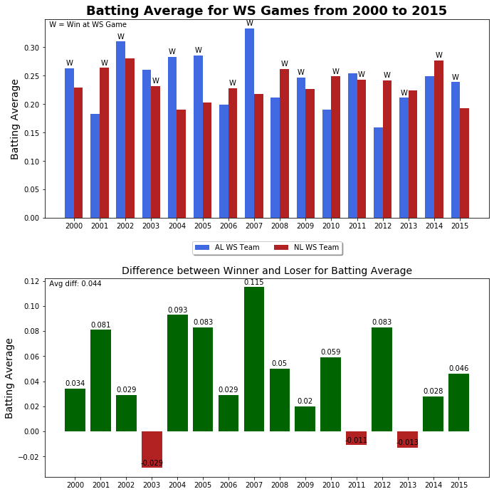

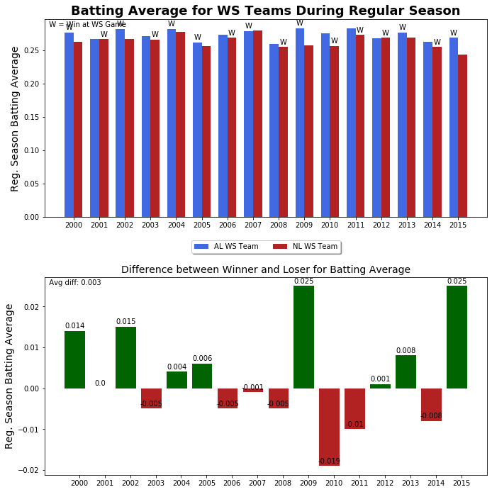

```python
BarChartWSStats(2000, 2015, 'BA')
```

4.1 Query Hall of Fame Players and Player Names

```python
halloffame_df = pd.read_sql_query('''

    SELECT*
    FROM hall_of_fame
    WHERE inducted = 'Y';
    ''', connection)

pd.set_option('display.max_rows',None)
halloffame_df
listHallofFame = halloffame_df['player_id'].values.tolist()
```

```python
playerNames_df = pd.read_sql_query('''

    SELECT*
    FROM player;
    ''', connection)

pd.set_option('display.max_columns',None)
```

```python
def nameGetter(playerIDList, df=playerNames_df):
    '''
    Input:   playerIDList - List of player_id
    Default:   df = playerNames_df
    Output:   fullName - List of the full name of players based on player_id
    '''
    First = []
    Last = []
    fullName = []

    for i in playerIDList:
        First.append(df.loc[df['player_id'] == i, 'name_first'].iloc[0])
        Last.append(df.loc[df['player_id'] == i, 'name_last'].iloc[0])

    fullName = [a +' '+ b for a, b in zip(First, Last)]

    return fullName
```

4.2 Detect Outliers

```python
def detectOutlier(data, stat, mlbORteamORplayer):
    '''
    Input:   df - Batting Stats Dataframe
    Input:   stat -  Ex. 'BA' 'OBP
    Input:   mlbORteamORplayer - 'mlb'  'team'  'player'
    Output: List of year and stat and label

    Detect values with the probabilty 0.135% or less of occuring in normal distribution.    0.135% -> Z scores > 3.00
    '''
    outlierYear = []
    outlierStat = []
    labelName = []

    mean = np.mean(data[stat])
    std = np.std(data[stat])

    if mlbORteamORplayer == 'player':
        labelType = 'player_id'
    elif mlbORteamORplayer == 'team':
        labelType = 'team_id'
    elif mlbORteamORplayer == 'mlb':
        labelType = 'year'

    # Create lists of year and stat and label when zscore greater than 3.
    for year, statValue, label in zip(data.loc[:, 'year'], data.loc[:, stat], data.loc[:, labelType] ):
        zScore = (statValue - mean)/std
        if zScore >3:
            outlierYear.append(year)
            outlierStat.append(statValue)
            labelName.append(label)

    return outlierYear, outlierStat, labelName
```

```python
def autoLabelPlot(outliersx, outliersy, outlierName):
    '''
    Text label above each bar displaying if WS win.
    '''
    for x,y, label in zip(outliersx, outliersy, outlierName):
         plt.annotate("{}".format(label), (x,y), xytext=(6,0), ha='left',  va='center', textcoords="offset points", alpha=.75)
```

4.3 League Outliers Plot

```python
def LeagueOutliers(mlbORteamORplayer, startYear, endYear, stat, team=None, dictStats=dictStats, df = regularSeason_df ,listHallofFame = listHallofFame, labelswitch=True):
    '''
    Input:   mlbORteamORplayer - 'mlb'  'team'  'player'
    Input:   startYear - Numerical year
    Input:   endYear - Numerical year
    Input:   stat -  Ex. 'BA' 'OBP
    Default:   dictStats - Dictionary of stat names
    Default:   df - Batting Stats Dataframe
    Default:     listHallofFame - List of Hall of Fame players
    Default:    labelswitch  -  Turn labels On/Off
    Output:      Leaders   - List out Outliers in order.

    Detect values with the probabilty 0.135% or less of occuring in normal distribution.    0.135% -> Z scores > 3.00
    '''

    #Used for histogram to select data of entire MLB league with either team=None    or team = list of teams.
    if team == None:
        dfnew = BattingStats(df, 'regular', mlbORteamORplayer, startYear, endYear, team)
        dfmlb = dfnew

    elif team is not None:
        print("Selected teams:" + str(team))
        dfnew = BattingStats(df, 'regular', mlbORteamORplayer, startYear, endYear, team)
        dfmlb = BattingStats(df, 'regular', mlbORteamORplayer, startYear, endYear, team = None)

    #-------------------------------------------------------------------------------------------------------------------------------------------------------------------------------------------

    if mlbORteamORplayer == 'player':
        # Select players with Plate Apperiences over 502 in AL and NL leagues.
        ALstat = dfnew[['year', 'player_id', stat]][(dfnew['league_id'] == "AL") & (dfnew['PA'] >502)]
        NLstat = dfnew[['year', 'player_id', stat]][(dfnew['league_id'] == "NL") & (dfnew['PA'] >502)]
        MLBstat = dfmlb[['year',  'player_id', stat]][(dfmlb['PA'] >502)]

        # Calculate average yearly stat
        ALPlayerAvg = ALstat.groupby(by=['year'], as_index=False).mean()
        NLPlayerAvg = NLstat.groupby(by=['year'], as_index=False).mean()

        # Select outliers with Z score > 3.
        ALoutliersx, ALoutliersy, ALoutlierName   = detectOutlier(ALstat, stat, mlbORteamORplayer)
        NLoutliersx, NLoutliersy, NLoutlierName  = detectOutlier(NLstat, stat, mlbORteamORplayer)

        # Check if these outliers are in the hall of fame
        if len(ALoutliersy) >0:
            dfHofFAL = ALstat[ALstat['player_id'].isin(listHallofFame)]
            dfHofFAL = dfHofFAL[dfHofFAL['player_id'].isin(ALoutlierName)]
            dfHofFAL = dfHofFAL[dfHofFAL[stat] >= min(ALoutliersy)]

        if len(NLoutliersy) >0:
            dfHofFNL = NLstat[NLstat['player_id'].isin(listHallofFame)]
            dfHofFNL = dfHofFNL[dfHofFNL['player_id'].isin(NLoutlierName)]
            dfHofFNL = dfHofFNL[dfHofFNL[stat] >= min(NLoutliersy)]

        # Get the full name of outlier players
        ALoutlierName = nameGetter(ALoutlierName)
        NLoutlierName = nameGetter(NLoutlierName)

     #-------------------------------------------------------------------------------------------------------------------------------------------------------------------------------------------

    elif mlbORteamORplayer == 'team':

        ALstat = dfnew[['year', 'team_id', stat]][(dfnew['league_id'] == "AL") ]
        NLstat = dfnew[['year', 'team_id', stat]][(dfnew['league_id'] == "NL") ]

        # Calculate average yearly stat
        ALTeamAvg = ALstat.groupby(by=['year'], as_index=False).mean()
        NLTeamAvg = NLstat.groupby(by=['year'], as_index=False).mean()

        # Select outliers with Z score > 3.
        ALoutliersx, ALoutliersy, ALoutlierName  = detectOutlier(ALstat, stat, mlbORteamORplayer)
        NLoutliersx, NLoutliersy, NLoutlierName  = detectOutlier(NLstat, stat, mlbORteamORplayer)

        # All teams.
        MLBstat = dfmlb[['year', 'team_id', stat]]

     #-------------------------------------------------------------------------------------------------------------------------------------------------------------------------------------------

    # Figure 1: Scatter Plot for Split Leagues
    fig1=plt.figure(figsize =(10,10))
    ax=fig1.add_axes([0,0,1,1])

    ax.scatter(ALstat['year'], ALstat[stat], label='AL League', color='royalblue', alpha=.4)
    ax.scatter(NLstat['year'], NLstat[stat], label='NL League', color='firebrick', alpha=.4)

    ax.scatter(ALoutliersx, ALoutliersy, label='Outliers Zscore > 3', color='k', marker = 'x')
    ax.scatter(NLoutliersx, NLoutliersy, color='k',  marker = 'x')

    if mlbORteamORplayer == 'player':
        ax.plot(ALPlayerAvg['year'], ALPlayerAvg[stat], label='AL League Avg', color='b', lw=3)
        ax.plot(NLPlayerAvg['year'], NLPlayerAvg[stat], label='NL League Avg', color='r', lw=3)
        if len(ALoutliersy) >0:
            ax.scatter(dfHofFAL['year'], dfHofFAL[stat], label='Hall of Fame Player',  facecolors='none', edgecolors='g')
        if len(NLoutliersy) >0:
            ax.scatter(dfHofFNL['year'], dfHofFNL[stat],  facecolors='none', edgecolors='g')

    elif mlbORteamORplayer == 'team':
        ax.plot(ALTeamAvg['year'], ALTeamAvg[stat], label='AL League Avg', color='b', lw=3)
        ax.plot(NLTeamAvg['year'], NLTeamAvg[stat], label='NL League Avg', color='r', lw=3)


    # Figure 1: Labels and titles.
    title = dictStats.get(stat)
    ax.set_title(title + ' per ' + mlbORteamORplayer.title() + ' for each League', fontweight = 'bold', fontsize=18)
    ax.set_ylabel(title + ' per ' + mlbORteamORplayer.title(), fontsize=16)
    plt.legend()

    if labelswitch==True:
        autoLabelPlot(ALoutliersx, ALoutliersy, ALoutlierName)
        autoLabelPlot(NLoutliersx, NLoutliersy, NLoutlierName)

     #-------------------------------------------------------------------------------------------------------------------------------------------------------------------------------------------

    # Bin size calculation
    q75, q25 = np.percentile(MLBstat[stat], [75 ,25])
    iqr = q75 - q25
    binsize = round(2*iqr*(len(MLBstat[stat])**(-1/3)),1)
    binsCalc = int((MLBstat[stat].max() - MLBstat[stat].min()) /(2*iqr*(len(MLBstat[stat])**(-1/3))))

    # Figure 2: Histogram of stats per league with total season in background
    fig2, axs = plt.subplots(nrows=1, ncols=2, figsize =(12,10), edgecolor='k', clear=True)
    fig2 = sns.distplot(ALstat[stat], hist=True, kde=False, bins=binsCalc, color = 'darkblue', ax=axs[0])
    fig2 = sns.distplot(MLBstat[stat], hist=True, kde=False, bins=binsCalc, color = 'grey', ax=axs[0])
    fig2 = sns.distplot(NLstat[stat], hist=True, kde=False,bins=binsCalc, color = 'darkred', ax=axs[1])
    fig2 = sns.distplot(MLBstat[stat], hist=True, kde=False, bins=binsCalc, color = 'grey', ax=axs[1])

    # Figure 2: Titles and labels
    axs[0].set_title('AL '+ title + ' Histogram', fontweight = 'bold', fontsize=18)
    axs[0].set_xlabel(title + ' per ' + mlbORteamORplayer.title(), fontsize=16)
    axs[0].set_ylabel('Frequency', fontsize=16)
    axs[1].set_title('NL '+ title + ' Histogram', fontweight = 'bold', fontsize=18)
    axs[1].set_xlabel(title + ' per ' + mlbORteamORplayer.title(), fontsize=16)
    axs[1].set_ylabel('Frequency', fontsize=16)

    # Figure 2: Mean and Standard Deviation
    avgMLBStat = round(np.mean(MLBstat[stat]), 3)
    avgALStat = round(np.mean(ALstat[stat]), 3)
    avgNLStat = round(np.mean(NLstat[stat]), 3)
    stdMLBStat = round(np.std(MLBstat[stat]), 3)
    stdALStat = round(np.std(ALstat[stat]), 3)
    stdNLStat = round(np.std(NLstat[stat]), 3)

    axs[0].text(1, 0.99, '  MLB Mean: '+  str(avgMLBStat), horizontalalignment='right', verticalalignment='top', transform=axs[0].transAxes)
    axs[0].text(1, 0.95, '  MLB STD: '+  str(stdMLBStat), horizontalalignment='right', verticalalignment='top', transform=axs[0].transAxes)
    axs[1].text(1, 0.99, '  MLB Mean: '+  str(avgMLBStat), horizontalalignment='right', verticalalignment='top', transform=axs[1].transAxes)
    axs[1].text(1, 0.95, '  MLB STD: '+  str(stdMLBStat), horizontalalignment='right', verticalalignment='top', transform=axs[1].transAxes)

    axs[0].text(1, 0.90, '  AL Mean: '+  str(avgALStat), horizontalalignment='right', verticalalignment='top', transform=axs[0].transAxes, color='royalblue')
    axs[0].text(1, 0.85, '  AL STD: '+  str(stdALStat), horizontalalignment='right', verticalalignment='top', transform=axs[0].transAxes, color='royalblue')
    axs[1].text(1, 0.90, '  NL Mean: '+  str(avgNLStat), horizontalalignment='right', verticalalignment='top', transform=axs[1].transAxes, color='firebrick')
    axs[1].text(1, 0.85, '  NL STD: '+  str(stdNLStat), horizontalalignment='right', verticalalignment='top', transform=axs[1].transAxes, color='firebrick')

    axs[1].text(1, 0.80, '  Bin Size: '+  str(binsize), horizontalalignment='right', verticalalignment='top', transform=axs[1].transAxes)
    axs[0].text(1, 0.80, '  Bin Size: '+  str(binsize), horizontalalignment='right', verticalalignment='top', transform=axs[0].transAxes)


 #-------------------------------------------------------------------------------------------------------------------------------------------------------------------------------------------

    # Figure 3: Histogram of stats per league with total season in background
    fig3, axs = plt.subplots(nrows=1, ncols=2, figsize =(12,10), edgecolor='k', clear=True)
    fig3 = sns.distplot(ALstat[stat], hist=True, kde=False, bins=binsCalc, color = 'darkblue', ax=axs[0])
    fig3 = sns.distplot(NLstat[stat], hist=True, kde=False,bins=binsCalc, color = 'darkred', ax=axs[1])

    # Figure 3: Titles and labels
    axs[0].set_title('AL '+ title + ' Histogram', fontsize=18, fontweight = 'bold')
    axs[0].set_xlabel(title + ' per ' + mlbORteamORplayer.title(), fontsize=16)
    axs[0].set_ylabel('Frequency', fontsize=16)
    axs[1].set_title('NL '+ title + ' Histogram', fontsize=18, fontweight = 'bold')
    axs[1].set_xlabel(title + ' per ' + mlbORteamORplayer.title(), fontsize=16)
    axs[1].set_ylabel('Frequency', fontsize=16)

    # Figure 3: Mean and Standard Deviation
    axs[0].text(1, 0.99, '  AL Mean: '+  str(avgALStat), horizontalalignment='right', verticalalignment='top', transform=axs[0].transAxes)
    axs[0].text(1, 0.95, '  AL STD: '+  str(stdALStat), horizontalalignment='right', verticalalignment='top', transform=axs[0].transAxes)
    axs[1].text(1, 0.99, '  NL Mean: '+  str(avgNLStat), horizontalalignment='right', verticalalignment='top', transform=axs[1].transAxes)
    axs[1].text(1, 0.95, '  NL STD: '+  str(stdNLStat), horizontalalignment='right', verticalalignment='top', transform=axs[1].transAxes)

    axs[1].text(1, 0.90, '  Bin Size: '+  str(binsize), horizontalalignment='right', verticalalignment='top', transform=axs[1].transAxes)
    axs[0].text(1, 0.90, '  Bin Size: '+  str(binsize), horizontalalignment='right', verticalalignment='top', transform=axs[0].transAxes)

 #-------------------------------------------------------------------------------------------------------------------------------------------------------------------------------------------

    # Leader board for both AL and NL league.
    # NOTE: Other leagues wont be added.
    Leaders = pd.DataFrame({ 'Name': ALoutlierName, stat: ALoutliersy, 'Year': ALoutliersx, 'League': ['AL']*len(ALoutlierName)})
    for x,y, z in zip(NLoutliersx, NLoutliersy, NLoutlierName ):
        Leaders = Leaders.append({ 'Name': z, stat: y, 'Year': x, 'League': 'NL'},  ignore_index=True)
    Leaders.sort_values(by=[stat], inplace=True, ascending=False)
    Leaders.reset_index(drop=True, inplace=True)

    return Leaders
```

4.4 MLB Outliers Plot

```python
def MLBOutliers(mlbORteamORplayer, startYear, endYear, stat, team=None, dictStats=dictStats, df = regularSeason_df , labelswitch=True):
    '''
    Input:   mlbORteamORplayer - 'mlb'  'team'  'player'
    Input:   startYear - Numerical year
    Input:   endYear - Numerical year
    Input:   stat -  Ex. 'BA' 'OBP
    Default:   team=None    - list of all teams
    Default:   dictStats - Dictionary of stat names
    Default:   df - Batting Stats Dataframe
    Default:    labelswitch  -  Turn labels On/Off
    Output:      Leaders   - List out Outliers in order.

    Detect values with the probabilty 0.135% or less of occuring in normal distribution.    0.135% -> Z scores > 3.00
    '''



    dfnew = BattingStats(df, 'regular', mlbORteamORplayer, startYear, endYear, team)
    title = dictStats.get(stat)

    if mlbORteamORplayer == 'player':
        # Select players with Plate Apperiences over 502
        dfnew = dfnew.groupby(by=['year', 'player_id'], as_index=False).sum()
        MLBstat = dfnew[['year', 'player_id', stat]][dfnew['PA'] >502]
        MLBstatAvg = MLBstat.groupby(by=['year'], as_index=False).mean()


        # Select outliers with Z score > 3
        MLBoutliersx, MLBoutliersy, MLBoutlierName  = detectOutlier(MLBstat, stat, mlbORteamORplayer)
        MLBoutlierName = nameGetter(MLBoutlierName)


#--------------------------------------------------------------------------------------------------------------------------------------------------------------------------------------------------

    elif mlbORteamORplayer == 'team':
        MLBstat = dfnew[['year', 'team_id', stat]]

        # Select outliers with Z score > 3
        MLBoutliersx, MLBoutliersy, MLBoutlierName  = detectOutlier(MLBstat, stat, mlbORteamORplayer)
        MLBstatAvg = dfnew.groupby(by=['year'], as_index=False).mean()

#--------------------------------------------------------------------------------------------------------------------------------------------------------------------------------------------------

    elif mlbORteamORplayer == 'mlb':
        MLBstat = dfnew[['year', stat]]
        MLBoutliersx, MLBoutliersy, MLBoutlierName  = detectOutlier(MLBstat, stat, mlbORteamORplayer)
        mlbORteamORplayer = 'year'
        MLBstatAvg = dfnew.groupby(by=['year'], as_index=False).mean()

#--------------------------------------------------------------------------------------------------------------------------------------------------------------------------------------------------

    # Figure 1: Scatter Plot for MLB
    fig1=plt.figure(figsize =(10,10))
    ax=fig1.add_axes([0,0,1,1])
    ax.scatter(MLBstat['year'], MLBstat[stat], label=title+  ' per ' + mlbORteamORplayer.title(), color='royalblue',alpha=.3)
    ax.scatter(MLBoutliersx, MLBoutliersy, label='Outliers Zscore > 3', color='k', marker = 'x')
    ax.plot(MLBstatAvg['year'], MLBstatAvg[stat], label='MLB Avg', color='b', lw=3)


    # Figure 1: Labels and titles.
    if labelswitch == True:
        autoLabelPlot(MLBoutliersx, MLBoutliersy, MLBoutlierName)
    ax.set_title(title + ' per ' + mlbORteamORplayer.title(), fontweight = 'bold', fontsize=18)
    ax.set_ylabel(title, fontsize=16)
    plt.legend()

    # Bin size calculation
    q75, q25 = np.percentile(MLBstat[stat], [75 ,25])
    iqr = q75 - q25
    binsCalc = int((MLBstat[stat].max() - MLBstat[stat].min()) /(2*iqr*(len(MLBstat[stat])**(-1/3))))

    # Figure 2: Histogram of stats
    fig2 = plt.figure( figsize =(10,10), edgecolor='k', clear=True)
    ax=fig2.add_axes([0,0,1,1])
    sns.distplot(MLBstat[stat], hist=True, kde=False, bins=binsCalc, color = 'royalblue')

    # Figure 2: Titles and labels
    ax.set_title(title + ' Histogram', fontweight = 'bold', fontsize=18)
    ax.set_xlabel(title + ' per ' + mlbORteamORplayer.title(), fontsize=16)
    ax.set_ylabel('Frequency', fontsize=16)

    # Leader board for both AL and NL league.
    # NOTE: Other leagues wont be added.
    Leaders = pd.DataFrame({ 'Name': MLBoutlierName, stat: MLBoutliersy, 'Year': MLBoutliersx})
    Leaders.sort_values(by=[stat, 'Name'], inplace=True, ascending=False)
    Leaders.reset_index(drop=True, inplace=True)

    return Leaders
```

4.5 Compare Stats Plot

```python
def MLBTwoStats(mlbORteamORplayer, startYear, endYear, stat1, stat2, team=None, dictStats=dictStats, df = regularSeason_df , PointsOn = True):
    '''
    Input:   mlbORteamORplayer - 'mlb'  'team'  'player'
    Input:   startYear - Numerical year
    Input:   endYear - Numerical year
    Input:   stat1 -  Ex. 'BA'
    Input:   stat2 -  Ex.  'OBP'
    Default:   team=None    - list of all teams
    Default:   dictStats - Dictionary of stat names
    Default:   df - Batting Stats Dataframe
    Default:    PointsOn  -  Markers On/Off
    '''

    dfnew = BattingStats(df, 'regular', mlbORteamORplayer, startYear, endYear, team)
    title1 = dictStats.get(stat1)
    title2 = dictStats.get(stat2)

    if mlbORteamORplayer == 'player':
        # Select players with Plate Apperiences over 502
        dfnew = dfnew.groupby(by=['year', 'player_id'], as_index=False).sum()
        MLBstat1 = dfnew[['year', 'player_id', stat1]][dfnew['PA'] >502]
        MLBstat2 = dfnew[['year', 'player_id', stat2]][dfnew['PA'] >502]


        MLBstatAvg1 = MLBstat1.groupby(by=['year'], as_index=False).mean()
        MLBstatAvg2 = MLBstat2.groupby(by=['year'], as_index=False).mean()
#--------------------------------------------------------------------------------------------------------------------------------------------------------------------------------------------------

    elif mlbORteamORplayer == 'team':
        MLBstat1 = dfnew[['year', 'team_id', stat1]]
        MLBstat2 = dfnew[['year', 'team_id', stat2]]
        # Select outliers with Z score > 3

        MLBstatAvg1 = MLBstat1.groupby(by=['year'], as_index=False).mean()
        MLBstatAvg2 = MLBstat2.groupby(by=['year'], as_index=False).mean()
#--------------------------------------------------------------------------------------------------------------------------------------------------------------------------------------------------

    elif mlbORteamORplayer == 'mlb':
        MLBstat1 = dfnew[['year', stat1]]
        MLBstat2 = dfnew[['year', stat2]]
        mlbORteamORplayer = 'year'
        MLBstatAvg1 = MLBstat1.groupby(by=['year'], as_index=False).mean()
        MLBstatAvg2 = MLBstat2.groupby(by=['year'], as_index=False).mean()
#--------------------------------------------------------------------------------------------------------------------------------------------------------------------------------------------------

    # Figure 1: Scatter Plot for MLB
    fig1=plt.figure(figsize =(10,10))
    ax=fig1.add_axes([0,0,1,1])
    ax2 = ax.twinx()
    if PointsOn == True:
        ax.scatter(MLBstat1['year'], MLBstat1[stat1], label=title1+  ' per ' + mlbORteamORplayer.title(), color='darkorange',alpha=.1)
        ax2.scatter(MLBstat2['year'], MLBstat2[stat2], label=title2 + ' per ' + mlbORteamORplayer.title(), color='darkgreen',alpha=.1)

    ax.plot(MLBstatAvg1['year'], MLBstatAvg1[stat1], label=title1 + ' Avg', color='darkorange', lw=3)
    ax2.plot(MLBstatAvg2['year'], MLBstatAvg2[stat2], label=title2+ ' Avg', color='darkgreen', lw=3)

    # Figure 1: Labels and titles.

    ax.set_title(title1 + ' VS ' + title2 + ' per ' + mlbORteamORplayer.title(), fontweight = 'bold', fontsize=18)
    ax.set_ylabel(title1, fontsize=16)
    ax2.set_ylabel(title2, fontsize=16)

    linesOne, labelsOne = ax.get_legend_handles_labels()
    linesTwo, labelsTwo = ax2.get_legend_handles_labels()
    lines = linesOne + linesTwo
    labels = labelsOne + labelsTwo
    ax.legend(lines, labels, loc=0)
```

5.1 Home Run Leaders per League

This function allows you to choose any stat and look for outliers (leaders). Each outlier in based on its respective league data being either AL or NL. This can be performed on either on a per player basis or per team basis.  
As a default all the teams are included however you can choose one or more teams by including a list in the function input. Example team=[‘NYN’, KCA’].  
Below the scatter plot there are histograms to show the distribution of the stat.  
To demonstrate I have chosen the home run stat and below you can see the record holders for homeruns in the two leagues.

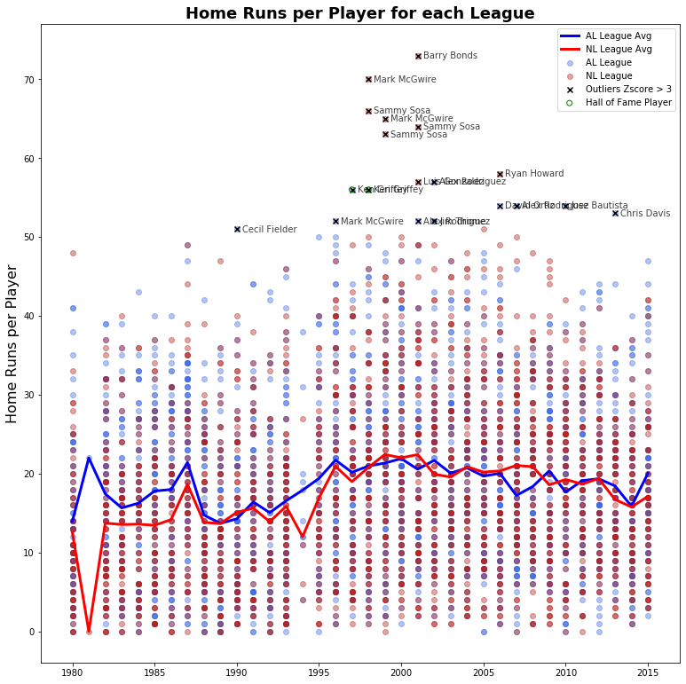

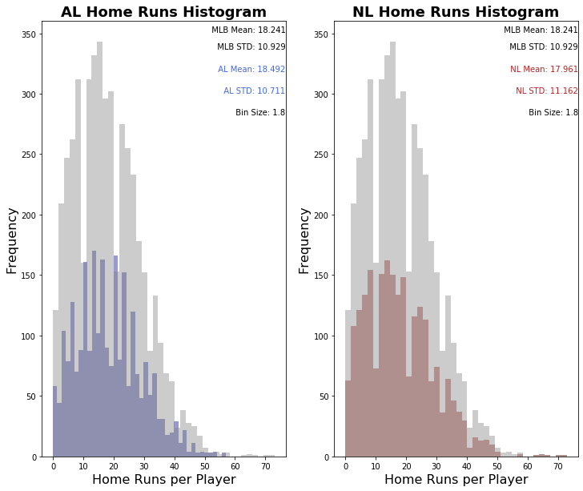

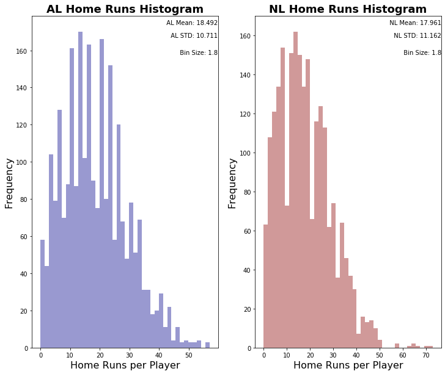

```python
Leaders = LeagueOutliers('player', 1980, 2015, 'hr',labelswitch=True)
```

# Top 10 Home Run Hitters per League

```python
Leaders.head(10)
```

|  | Name | hr | Year | League |
| --- | --- | --- | --- | --- |
| 0 | Barry Bonds | 73.0 | 2001 | NL |
| 1 | Mark McGwire | 70.0 | 1998 | NL |
| 2 | Sammy Sosa | 66.0 | 1998 | NL |
| 3 | Mark McGwire | 65.0 | 1999 | NL |
| 4 | Sammy Sosa | 64.0 | 2001 | NL |
| 5 | Sammy Sosa | 63.0 | 1999 | NL |
| 6 | Ryan Howard | 58.0 | 2006 | NL |
| 7 | Alex Rodriguez | 57.0 | 2002 | AL |
| 8 | Luis Gonzalez | 57.0 | 2001 | NL |
| 9 | Ken Griffey | 56.0 | 1997 | AL |

5.2 Home Run Leaders in MLB

This function allows you to choose any stat and look for outliers (leaders). Each outlier in based on the entire MLB data set. This can be performed on either on a per player basis or per team basis or per MLB season.  
As a default all the teams are included however you can choose one or more teams by including a list in the function input. Example team=[‘NYN’, KCA’].  
Below the scatter plot there are histograms to show the distribution of the stat.  
To demonstrate I have chosen the home run stat and below you can see the record holders for homeruns in all of MLB.

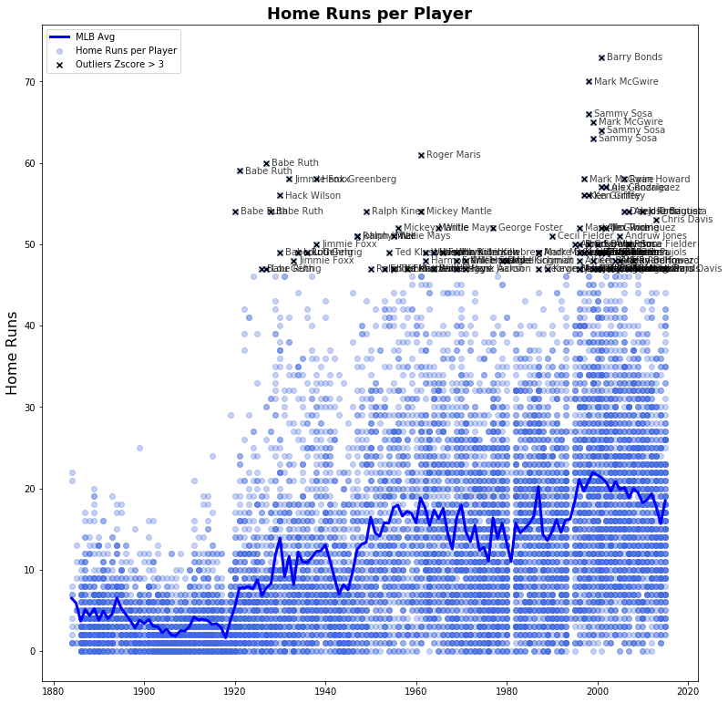

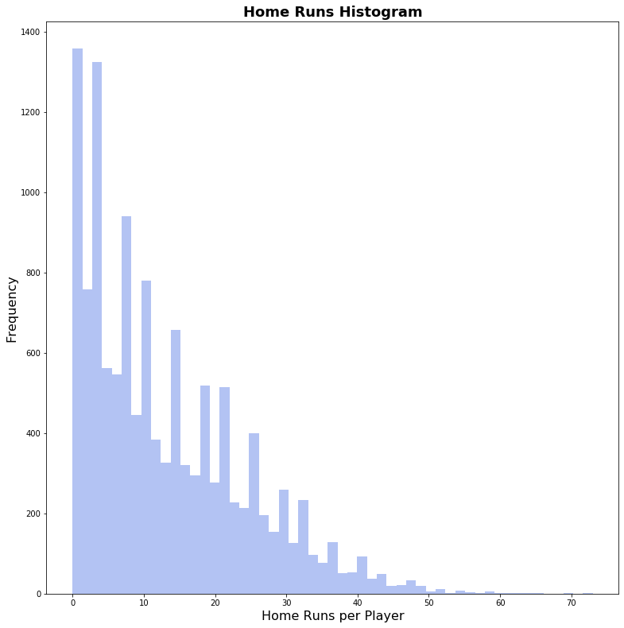

```python
Leaders = MLBOutliers('player', 1871, 2015, 'hr', labelswitch=True)
```

# Top 10 Home Run Hitters in MLB

```python
Leaders.head(10)
```

|  | Name | hr | Year |
| --- | --- | --- | --- |
| 0 | Barry Bonds | 73.0 | 2001 |
| 1 | Mark McGwire | 70.0 | 1998 |
| 2 | Sammy Sosa | 66.0 | 1998 |
| 3 | Mark McGwire | 65.0 | 1999 |
| 4 | Sammy Sosa | 64.0 | 2001 |
| 5 | Sammy Sosa | 63.0 | 1999 |
| 6 | Roger Maris | 61.0 | 1961 |
| 7 | Babe Ruth | 60.0 | 1927 |
| 8 | Babe Ruth | 59.0 | 1921 |
| 9 | Ryan Howard | 58.0 | 2006 |

5.3 Compare Stats

This function allows you to compare any two stats based on either average player total, average team total or season total. As a default, all the teams are included however you can choose one or more teams by including a list in the function input. Example team=[‘NYN’, KCA’].  
To demonstrate, as you can see below as home runs increased so did strike outs. This would lead me to believe that players are swinging more recklessly to try and get more home runs.

## Player Stats Compare

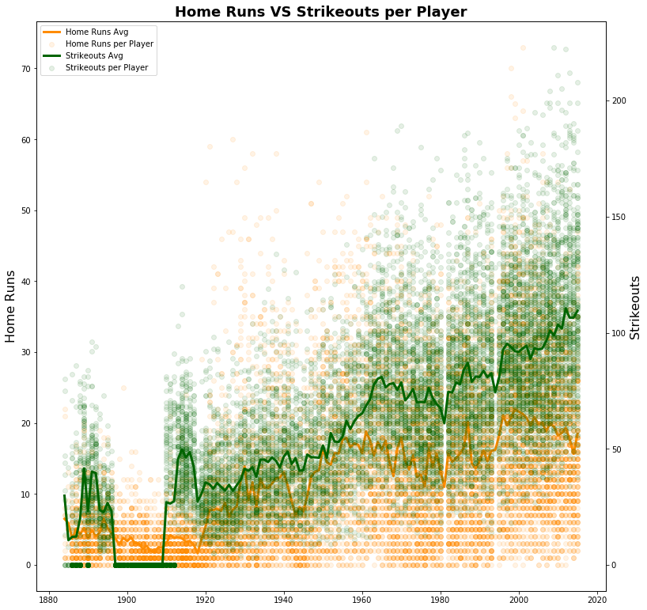

```python
MLBTwoStats('player', 1871, 2015, 'hr', 'so', PointsOn=True)
```

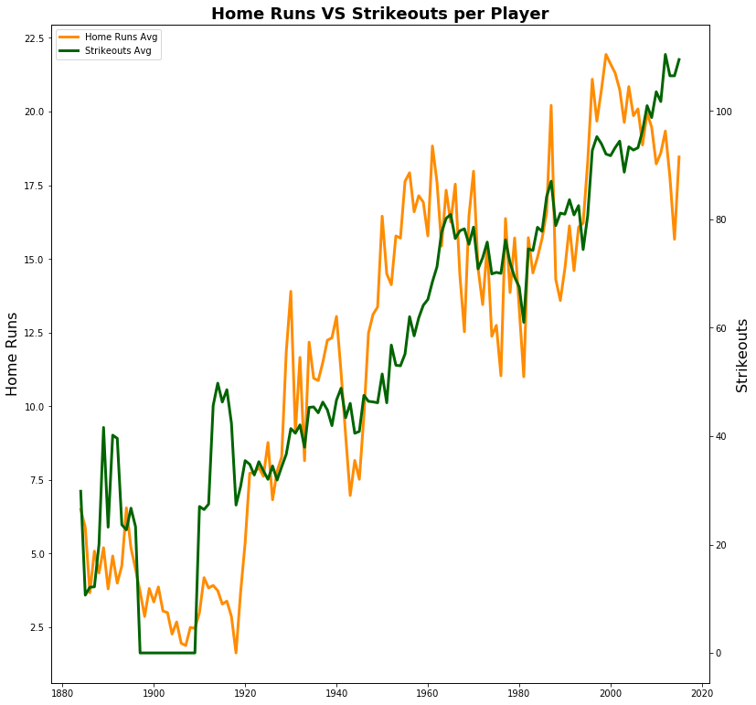

```python
MLBTwoStats('player', 1871, 2015, 'hr', 'so', PointsOn=False)
```

## Team Stats Compare

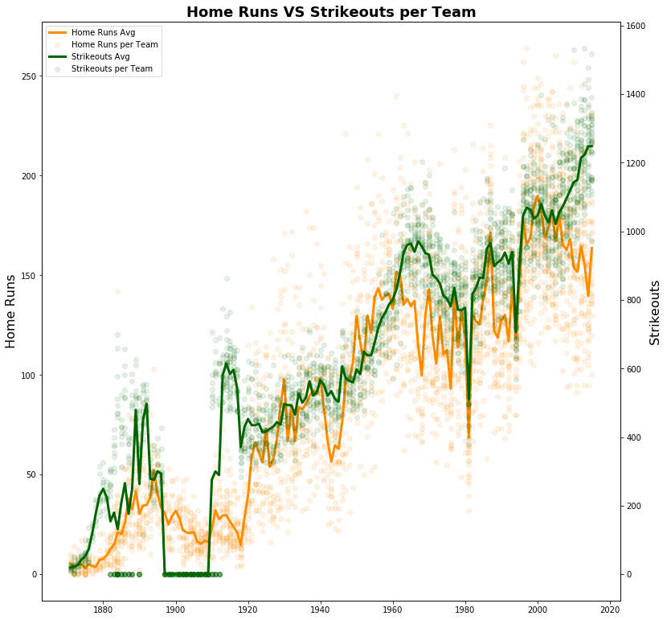

```python
MLBTwoStats('team', 1871, 2015, 'hr', 'so', PointsOn=True)
```

## MLB Stats Compare

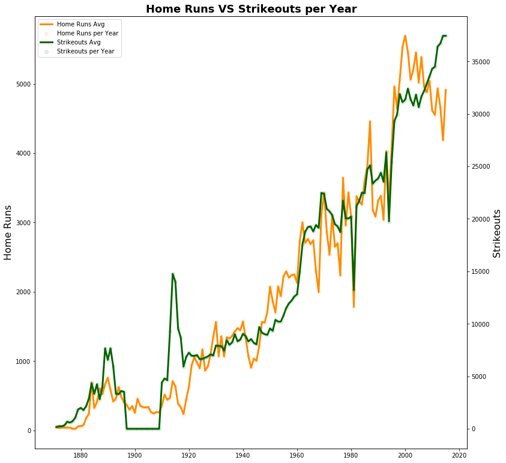

```python
MLBTwoStats('mlb', 1871, 2015, 'hr', 'so', PointsOn=True)
```

5.4 Triple Crown

In baseball, a player earns a Triple Crown when he leads a league in three specific statistical categories in the same season. The term "Triple Crown" generally refers to the batting achievement of leading a league in batting average, home runs, and runs batted in (RBI) over the same season.  
Source: https://en.wikipedia.org/wiki/Triple_Crown_(baseball)

```python
dfStatsTC = BattingStats(regularSeason_df, 'regular', 'player', 1871, 2015, team=None)
dfStatsTC['PAperG'] = dfStatsTC.loc[:,'PA'] / dfStatsTC.loc[:,'g']
dfStatsTC = dfStatsTC[:][dfStatsTC['PA'] >502]
dfStatsTC['BAmax'] = dfStatsTC.groupby(['year','league_id'])['BA'].transform(max)
dfStatsTC['hrmax'] = dfStatsTC.groupby(['year','league_id'])['hr'].transform(max)
dfStatsTC['rbimax'] = dfStatsTC.groupby(['year','league_id'])['rbi'].transform(max)

TCplayers=[]
TCyear=[]
TCBA=[]
TChr=[]
TCrbi=[]

    # Create lists of year and stat and label when zscore greater than 3.
for player_id, year, BA, BAmax, hr, hrmax, rbi, rbimax in zip(dfStatsTC.loc[:, 'player_id'],dfStatsTC.loc[:, 'year'], dfStatsTC.loc[:, 'BA'], dfStatsTC.loc[:, 'BAmax'], dfStatsTC.loc[:, 'hr'], dfStatsTC.loc[:, 'hrmax'], dfStatsTC.loc[:, 'rbi'], dfStatsTC.loc[:, 'rbimax'] ):
    if BA == BAmax:
        if hr == hrmax:
            if rbi == rbimax:
                TCplayers.append(player_id)
                TCyear.append(year)
                TCBA.append(BA)
                TChr.append(hr)
                TCrbi.append(rbi)

TCplayers =nameGetter(TCplayers, df=playerNames_df)
TCdf = pd.DataFrame(list(zip(TCyear, TCplayers, TCBA, TChr, TCrbi  )), columns =['Year', 'Name', 'BA', 'HR', 'RBI'])
TCdf
```

|  | Year | Name | BA | HR | RBI |
| --- | --- | --- | --- | --- | --- |
| 0 | 1884 | Charley Jones | 0.314 | 7.0 | 71.0 |
| 1 | 1887 | Tip O'Neill | 0.435 | 14.0 | 123.0 |
| 2 | 1894 | Hugh Duffy | 0.440 | 18.0 | 145.0 |
| 3 | 1901 | Nap Lajoie | 0.426 | 14.0 | 125.0 |
| 4 | 1909 | Ty Cobb | 0.377 | 9.0 | 107.0 |
| 5 | 1922 | Rogers Hornsby | 0.401 | 42.0 | 152.0 |
| 6 | 1925 | Rogers Hornsby | 0.403 | 39.0 | 143.0 |
| 7 | 1932 | Jimmie Foxx | 0.364 | 58.0 | 169.0 |
| 8 | 1933 | Jimmie Foxx | 0.356 | 48.0 | 163.0 |
| 9 | 1933 | Chuck Klein | 0.368 | 28.0 | 120.0 |
| 10 | 1934 | Lou Gehrig | 0.363 | 49.0 | 165.0 |
| 11 | 1937 | Joe Medwick | 0.374 | 31.0 | 154.0 |
| 12 | 1942 | Ted Williams | 0.356 | 36.0 | 137.0 |
| 13 | 1947 | Ted Williams | 0.343 | 32.0 | 114.0 |
| 14 | 1949 | Ted Williams | 0.343 | 43.0 | 159.0 |
| 15 | 1956 | Mickey Mantle | 0.353 | 52.0 | 130.0 |
| 16 | 1966 | Frank Robinson | 0.316 | 49.0 | 122.0 |
| 17 | 1967 | Carl Yastrzemski | 0.326 | 44.0 | 121.0 |
| 18 | 1981 | Dwight Evans | 0.296 | 22.0 | 71.0 |
| 19 | 1981 | Ozzie Smith | 0.222 | 0.0 | 21.0 |
| 20 | 1994 | Frank Thomas | 0.353 | 38.0 | 101.0 |
| 21 | 2012 | Miguel Cabrera | 0.330 | 44.0 | 139.0 |

```python
connection.close()
```